# Homework 3

Halenur Kocaman

## Libraries

The necessary libraries for the homework can be found below:

```r
library(readxl)
library(tidyverse)
library(dplyr)
library(ggplot2)
library(glmnet)
```

## Reading the Data

The data is imported and prepared for the tasks.

```r
df<-read.csv("C:/Users/asus/Desktop/elektrik.csv")
df<-cbind(df[,1:2],consumption=df[,3])
head(df[with(df, order("Tarih", "Saat"))])
```

```
##        Tarih
## 1 01.01.2016
## 2 01.01.2016
## 3 01.01.2016
## 4 01.01.2016
## 5 01.01.2016
## 6 01.01.2016
```

```r
index<-c(1:nrow(df))
df<-cbind(index=index,df)
#plot(df$index[c(1:100)],df$consumption[c(1:100)])
```

Before adding lagged columns, data structure is checked. Since the consumption feature is not numeric, lag operation could not be applied. Therefore, the data type of electricity consumption is changed to numeric. After adding 48 and 168 observations lagged columns, data is splitting to test and train sets.

```r
str(df)
```

```
## 'data.frame':    43128 obs. of  4 variables:
##  $ index      : int  1 2 3 4 5 6 7 8 9 10 ...
##  $ Tarih      : Factor w/ 1797 levels "01.01.2016","01.01.2017",..: 1 1 1 1 1 1 1 1 1 1 ...
##  $ Saat       : Factor w/ 24 levels "00:00","01:00",..: 1 2 3 4 5 6 7 8 9 10 ...
##  $ consumption: Factor w/ 42598 levels "0,00","15.333,30",..: 4411 2337 1051 542 426 417 469 390 814 2625 ...
```

```r
df$consumption<-as.numeric(df$consumption)
df$lagged_48<-lag(df$consumption,48)
df$lagged_168<-lag(df$consumption,168)
test_df<-df[-c(1:42385),]
train_df<-df[c(1:42385),][-c(1:168),]
```

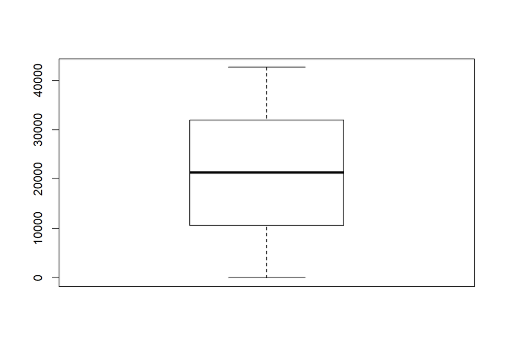

```r
boxplot(df$consumption)
```

## Task 1

The first task uses a naive approach to predict the consumption. Plot below shows that consumption of two days ago and today’s consumption are correlated.

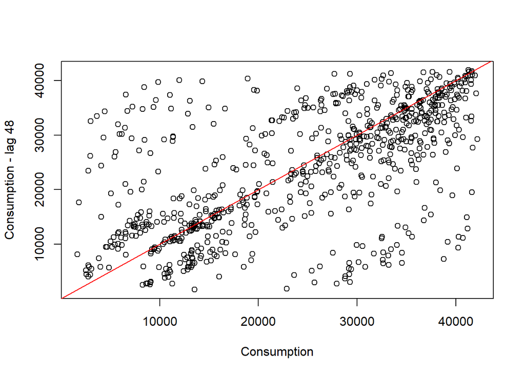

```r
plot(test_df$consumption,test_df$lagged_48,xlab ="Consumption",ylab="Consumption - lag 48")
abline(a=0,b=1,col=2)
```

Plot below shows that consumption of one week ago and today’s consumption have a strong relationship.

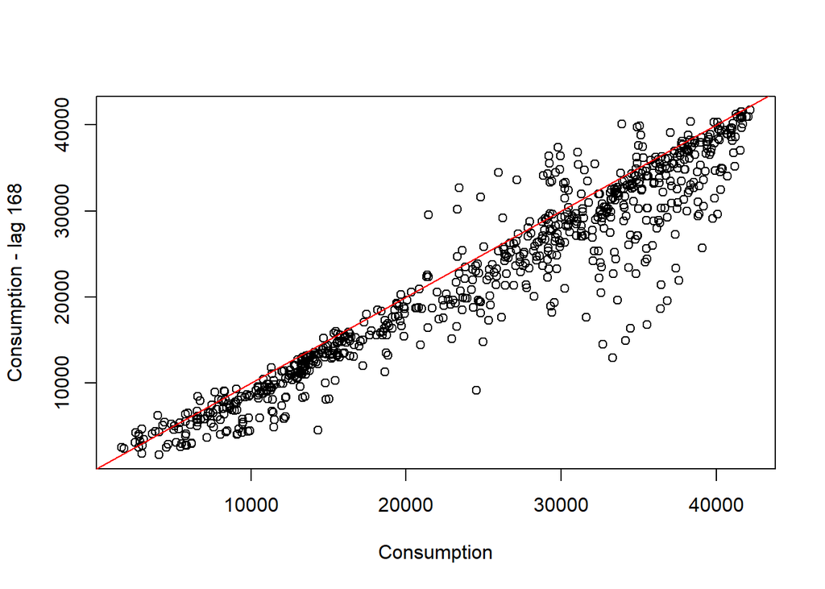

```r
plot(test_df$consumption,test_df$lagged_168,xlab ="Consumption",ylab="Consumption - lag 168")
abline(a=0,b=1,col=2)
```

The mape scores calculated from the test data for both naive approaches can be found below. Using one week ago electricity consumption as a naive approach has a better performance than using lag 48 data.

```r
ape_t1_48<-abs(test_df$lagged_48/test_df$consumption)
mape_48<-mean(abs(test_df$lagged_48/test_df$consumption))
ape_t1_168<-abs(test_df$lagged_168/test_df$consumption)
mape_168<-mean(abs(test_df$lagged_168/test_df$consumption))
mape_scores<-cbind(naive_lag_168=mape_168,naive_lag_48=mape_48)
mape_scores
```

```
##      naive_lag_168 naive_lag_48
## [1,]     0.8926363     1.185193
```

## TASK 2

In this part, lag 48 and lag 168 data are used as features to build a linear regression model. P-values shows that null hypothesis is rejected which shows that model parameters are different from zero. R squared value of the model is 0.79.

```r
fit<-lm(consumption~lagged_48+lagged_168,data=train_df)
summary(fit)
```

```
##
## Call:
## lm(formula = consumption ~ lagged_48 + lagged_168, data = train_df)
##
## Residuals:
##    Min     1Q Median     3Q    Max
## -38780  -2233      9   2327  35329
##
## Coefficients:
##              Estimate Std. Error t value Pr(>|t|)
## (Intercept) 9.147e+02  5.839e+01   15.67   <2e-16 ***
## lagged_48   2.806e-01  2.994e-03   93.72   <2e-16 ***
## lagged_168  6.762e-01  2.992e-03  226.00   <2e-16 ***
## ---
## Signif. codes:  0 '***' 0.001 '**' 0.01 '*' 0.05 '.' 0.1 ' ' 1
##
## Residual standard error: 5605 on 42214 degrees of freedom
## Multiple R-squared:  0.7917, Adjusted R-squared:  0.7917
## F-statistic: 8.021e+04 on 2 and 42214 DF,  p-value: < 2.2e-16
```

Using the test data, predictions are calculated. Plot below shows the prediction and actualization of the electricity consumption. It shows that the model is good to predict the consumption data.

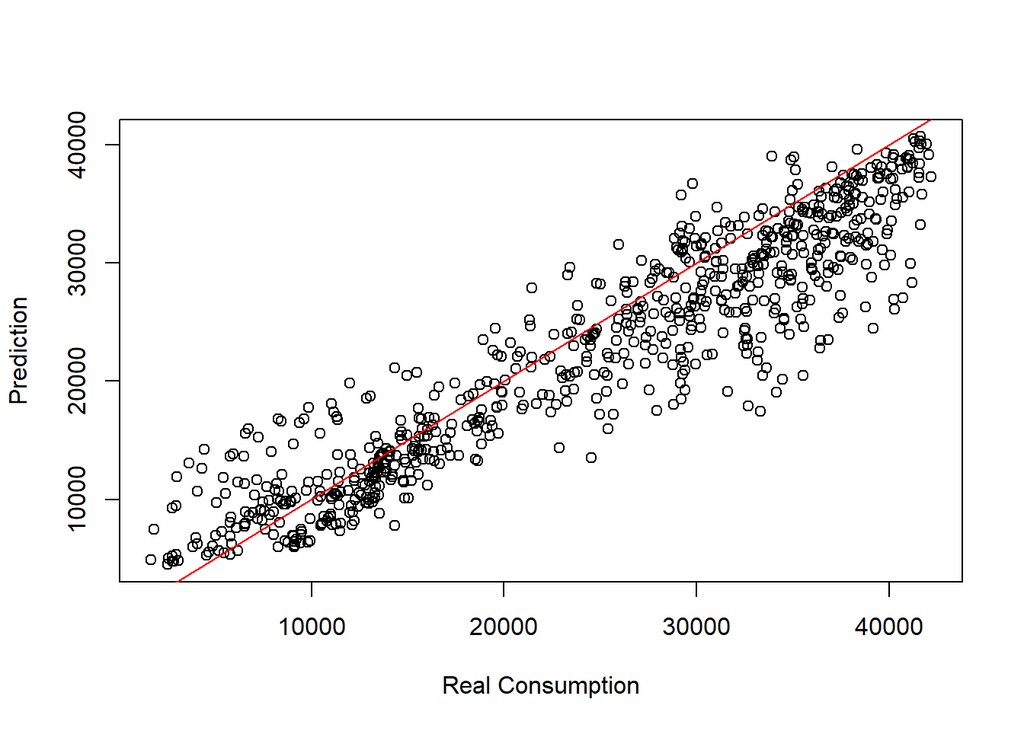

```r
prediction<-predict(fit,test_df[,5:6])
plot(test_df$consumption,prediction, xlab="Real Consumption", ylab="Prediction")
abline(a=0,b=1,col=2)
```

Mape score for this linear regression model is calculated. This linear regression model’s test performance is between lagged naive approaches with the score of 0.99.

```r
ape_t2<-abs(prediction/test_df$consumption)
mape_reg<-mean(abs(prediction/test_df$consumption))
mape_scores_2<-cbind(mape_scores,mape_reg)
mape_scores_2
```

```
##      naive_lag_168 naive_lag_48  mape_reg
## [1,]     0.8926363     1.185193 0.9923565
```

## TASK 3

In this part, the data is splitted hourly and models are constructed using the same features in the previous task. A better fit is expected since hourly seasonality may impact on electricity consumption and coefficients of each hourly model may differ.

### Model for 00:00

```r
train_0<-filter(train_df, Saat=="00:00")
test_0<-filter(test_df, Saat=="00:00")
fit_0<-lm(consumption~lagged_48+lagged_168,data=train_0)
summary(fit_0)
```

```
##
## Call:
## lm(formula = consumption ~ lagged_48 + lagged_168, data = train_0)
##
## Residuals:
##      Min       1Q   Median       3Q      Max
## -19824.8  -2136.1     85.2   2184.2  17562.4
##
## Coefficients:
##              Estimate Std. Error t value Pr(>|t|)
## (Intercept) 1.062e+03  2.400e+02   4.424 1.03e-05 ***
## lagged_48   4.843e-01  1.670e-02  28.996  < 2e-16 ***
## lagged_168  4.532e-01  1.667e-02  27.188  < 2e-16 ***
## ---
## Signif. codes:  0 '***' 0.001 '**' 0.01 '*' 0.05 '.' 0.1 ' ' 1
##
## Residual standard error: 4034 on 1757 degrees of freedom
## Multiple R-squared:  0.746,  Adjusted R-squared:  0.7457
## F-statistic:  2580 on 2 and 1757 DF,  p-value: < 2.2e-16
```

```r
prediction_0<-predict(fit_0,test_0[,5:6])
ae_0<-abs(prediction_0/test_0$consumption)
```

### Model for 01:00

```r
train_1<-filter(train_df, Saat=="01:00")
test_1<-filter(test_df, Saat=="01:00")
fit_1<-lm(consumption~lagged_48+lagged_168,data=train_1)
summary(fit_1)
```

```
##
## Call:
## lm(formula = consumption ~ lagged_48 + lagged_168, data = train_1)
##
## Residuals:
##      Min       1Q   Median       3Q      Max
## -19207.7  -2021.1     62.9   1896.3  17249.7
##
## Coefficients:
##              Estimate Std. Error t value Pr(>|t|)
## (Intercept) 779.36897  187.31977   4.161 3.33e-05 ***
## lagged_48     0.47025    0.01660  28.324  < 2e-16 ***
## lagged_168    0.46992    0.01657  28.357  < 2e-16 ***
## ---
## Signif. codes:  0 '***' 0.001 '**' 0.01 '*' 0.05 '.' 0.1 ' ' 1
##
## Residual standard error: 3703 on 1756 degrees of freedom
## Multiple R-squared:  0.7529, Adjusted R-squared:  0.7526
## F-statistic:  2675 on 2 and 1756 DF,  p-value: < 2.2e-16
```

```r
prediction_1<-predict(fit_1,test_1[,5:6])
ae_1<-abs(prediction_1/test_1$consumption)
```

### Model for 02:00

```r
train_2<-filter(train_df, Saat=="02:00")
test_2<-filter(test_df, Saat=="02:00")
fit_2<-lm(consumption~lagged_48+lagged_168,data=train_2)
summary(fit_2)
```

```
##
## Call:
## lm(formula = consumption ~ lagged_48 + lagged_168, data = train_2)
##
## Residuals:
##      Min       1Q   Median       3Q      Max
## -19289.1  -1817.7    -41.8   1722.5  14777.2
##
## Coefficients:
##              Estimate Std. Error t value Pr(>|t|)
## (Intercept) 622.20868  153.89596   4.043  5.5e-05 ***
## lagged_48     0.46185    0.01660  27.829  < 2e-16 ***
## lagged_168    0.47796    0.01657  28.849  < 2e-16 ***
## ---
## Signif. codes:  0 '***' 0.001 '**' 0.01 '*' 0.05 '.' 0.1 ' ' 1
##
## Residual standard error: 3347 on 1756 degrees of freedom
## Multiple R-squared:  0.7508, Adjusted R-squared:  0.7506
## F-statistic:  2646 on 2 and 1756 DF,  p-value: < 2.2e-16
```

```r
prediction_2<-predict(fit_2,test_2[,5:6])
ae_2<-abs(prediction_2/test_2$consumption)
```

### Model for 03:00

```r
train_3<-filter(train_df, Saat=="03:00")
test_3<-filter(test_df, Saat=="03:00")
fit_3<-lm(consumption~lagged_48+lagged_168,data=train_3)
summary(fit_3)
```

```
##
## Call:
## lm(formula = consumption ~ lagged_48 + lagged_168, data = train_3)
##
## Residuals:
##      Min       1Q   Median       3Q      Max
## -18478.3  -1649.6   -121.1   1550.0  14061.7
##
## Coefficients:
##              Estimate Std. Error t value Pr(>|t|)
## (Intercept) 509.65927  131.23974   3.883 0.000107 ***
## lagged_48     0.45102    0.01654  27.272  < 2e-16 ***
## lagged_168    0.49003    0.01652  29.671  < 2e-16 ***
## ---
## Signif. codes:  0 '***' 0.001 '**' 0.01 '*' 0.05 '.' 0.1 ' ' 1
##
## Residual standard error: 3027 on 1755 degrees of freedom
## Multiple R-squared:  0.7531, Adjusted R-squared:  0.7528
## F-statistic:  2676 on 2 and 1755 DF,  p-value: < 2.2e-16
```

```r
prediction_3<-predict(fit_3,test_3[,5:6])
ae_3<-abs(prediction_3/test_3$consumption)
```

### Model for 04:00

```r
train_4<-filter(train_df, Saat=="04:00")
test_4<-filter(test_df, Saat=="04:00")
fit_4<-lm(consumption~lagged_48+lagged_168,data=train_4)
summary(fit_4)
```

```
##
## Call:
## lm(formula = consumption ~ lagged_48 + lagged_168, data = train_4)
##
## Residuals:
##    Min     1Q Median     3Q    Max
## -17857  -1540   -156   1467  13910
##
## Coefficients:
##              Estimate Std. Error t value Pr(>|t|)
## (Intercept) 454.31384  120.93519   3.757 0.000178 ***
## lagged_48     0.42543    0.01636  26.007  < 2e-16 ***
## lagged_168    0.51695    0.01633  31.649  < 2e-16 ***
## ---
## Signif. codes:  0 '***' 0.001 '**' 0.01 '*' 0.05 '.' 0.1 ' ' 1
##
## Residual standard error: 2835 on 1757 degrees of freedom
## Multiple R-squared:  0.7522, Adjusted R-squared:  0.7519
## F-statistic:  2666 on 2 and 1757 DF,  p-value: < 2.2e-16
```

```r
prediction_4<-predict(fit_4,test_4[,5:6])
ae_4<-abs(prediction_4/test_4$consumption)
```

### Model for 05:00

```r
train_5<-filter(train_df, Saat=="05:00")
test_5<-filter(test_df, Saat=="05:00")
fit_5<-lm(consumption~lagged_48+lagged_168,data=train_5)
summary(fit_5)
```

```
##
## Call:
## lm(formula = consumption ~ lagged_48 + lagged_168, data = train_5)
##
## Residuals:
##      Min       1Q   Median       3Q      Max
## -16734.9  -1437.0   -170.5   1330.1  14145.7
##
## Coefficients:
##              Estimate Std. Error t value Pr(>|t|)
## (Intercept) 451.47505  118.08243   3.823 0.000136 ***
## lagged_48     0.36195    0.01604  22.565  < 2e-16 ***
## lagged_168    0.57787    0.01602  36.077  < 2e-16 ***
## ---
## Signif. codes:  0 '***' 0.001 '**' 0.01 '*' 0.05 '.' 0.1 ' ' 1
##
## Residual standard error: 2673 on 1756 degrees of freedom
## Multiple R-squared:  0.7369, Adjusted R-squared:  0.7366
## F-statistic:  2459 on 2 and 1756 DF,  p-value: < 2.2e-16
```

```r
prediction_5<-predict(fit_5,test_5[,5:6])
ae_5<-abs(prediction_5/test_5$consumption)
```

### Model for 06:00

```r
train_6<-filter(train_df, Saat=="06:00")
test_6<-filter(test_df, Saat=="06:00")
fit_6<-lm(consumption~lagged_48+lagged_168,data=train_6)
summary(fit_6)
```

```
##
## Call:
## lm(formula = consumption ~ lagged_48 + lagged_168, data = train_6)
##
## Residuals:
##      Min       1Q   Median       3Q      Max
## -16198.1  -1322.1   -176.8   1350.2  12719.9
##
## Coefficients:
##              Estimate Std. Error t value Pr(>|t|)
## (Intercept) 488.71182  126.05984   3.877  0.00011 ***
## lagged_48     0.26693    0.01519  17.579  < 2e-16 ***
## lagged_168    0.67094    0.01516  44.245  < 2e-16 ***
## ---
## Signif. codes:  0 '***' 0.001 '**' 0.01 '*' 0.05 '.' 0.1 ' ' 1
##
## Residual standard error: 2692 on 1756 degrees of freedom
## Multiple R-squared:  0.7286, Adjusted R-squared:  0.7283
## F-statistic:  2357 on 2 and 1756 DF,  p-value: < 2.2e-16
```

```r
prediction_6<-predict(fit_6,test_6[,5:6])
ae_6<-abs(prediction_6/test_6$consumption)
```

### Model for 07:00

```r
train_7<-filter(train_df, Saat=="07:00")
test_7<-filter(test_df, Saat=="07:00")
fit_7<-lm(consumption~lagged_48+lagged_168,data=train_7)
summary(fit_7)
```

```
##
## Call:
## lm(formula = consumption ~ lagged_48 + lagged_168, data = train_7)
##
## Residuals:
##      Min       1Q   Median       3Q      Max
## -20324.0  -1828.5   -156.5   1843.8  19866.5
##
## Coefficients:
##              Estimate Std. Error t value Pr(>|t|)
## (Intercept) 734.88763  183.45988   4.006 6.44e-05 ***
## lagged_48     0.19749    0.01438  13.732  < 2e-16 ***
## lagged_168    0.73476    0.01436  51.151  < 2e-16 ***
## ---
## Signif. codes:  0 '***' 0.001 '**' 0.01 '*' 0.05 '.' 0.1 ' ' 1
##
## Residual standard error: 3625 on 1756 degrees of freedom
## Multiple R-squared:  0.7123, Adjusted R-squared:  0.712
## F-statistic:  2174 on 2 and 1756 DF,  p-value: < 2.2e-16
```

```r
prediction_7<-predict(fit_7,test_7[,5:6])
ae_7<-abs(prediction_7/test_7$consumption)
```

### Model for 08:00

```r
train_8<-filter(train_df, Saat=="08:00")
test_8<-filter(test_df, Saat=="08:00")
fit_8<-lm(consumption~lagged_48+lagged_168,data=train_8)
summary(fit_8)
```

```
##
## Call:
## lm(formula = consumption ~ lagged_48 + lagged_168, data = train_8)
##
## Residuals:
##    Min     1Q Median     3Q    Max
## -32118  -2876     83   2763  31738
##
## Coefficients:
##              Estimate Std. Error t value Pr(>|t|)
## (Intercept) 1.811e+03  3.834e+02   4.724  2.5e-06 ***
## lagged_48   1.404e-01  1.423e-02   9.869  < 2e-16 ***
## lagged_168  7.696e-01  1.421e-02  54.150  < 2e-16 ***
## ---
## Signif. codes:  0 '***' 0.001 '**' 0.01 '*' 0.05 '.' 0.1 ' ' 1
##
## Residual standard error: 6181 on 1756 degrees of freedom
## Multiple R-squared:  0.6643, Adjusted R-squared:  0.664
## F-statistic:  1738 on 2 and 1756 DF,  p-value: < 2.2e-16
```

```r
prediction_8<-predict(fit_8,test_8[,5:6])
ae_8<-abs(prediction_8/test_8$consumption)
```

### Model for 09:00

```r
train_9<-filter(train_df, Saat=="09:00")
test_9<-filter(test_df, Saat=="09:00")
fit_9<-lm(consumption~lagged_48+lagged_168,data=train_9)
summary(fit_9)
```

```
##
## Call:
## lm(formula = consumption ~ lagged_48 + lagged_168, data = train_9)
##
## Residuals:
##    Min     1Q Median     3Q    Max
## -36541  -3215    391   3132  34560
##
## Coefficients:
##              Estimate Std. Error t value Pr(>|t|)
## (Intercept) 2.562e+03  5.093e+02    5.03 5.41e-07 ***
## lagged_48   1.486e-01  1.480e-02   10.04  < 2e-16 ***
## lagged_168  7.506e-01  1.479e-02   50.76  < 2e-16 ***
## ---
## Signif. codes:  0 '***' 0.001 '**' 0.01 '*' 0.05 '.' 0.1 ' ' 1
##
## Residual standard error: 7202 on 1756 degrees of freedom
## Multiple R-squared:   0.63,  Adjusted R-squared:  0.6296
## F-statistic:  1495 on 2 and 1756 DF,  p-value: < 2.2e-16
```

```r
prediction_9<-predict(fit_9,test_9[,5:6])
ae_9<-abs(prediction_9/test_9$consumption)
```

### Model for 10:00

```r
train_10<-filter(train_df, Saat=="10:00")
test_10<-filter(test_df, Saat=="10:00")
fit_10<-lm(consumption~lagged_48+lagged_168,data=train_10)
summary(fit_10)
```

```
##
## Call:
## lm(formula = consumption ~ lagged_48 + lagged_168, data = train_10)
##
## Residuals:
##    Min     1Q Median     3Q    Max
## -37762  -3243    521   3212  34582
##
## Coefficients:
##              Estimate Std. Error t value Pr(>|t|)
## (Intercept) 2.833e+03  5.483e+02   5.166 2.66e-07 ***
## lagged_48   1.796e-01  1.544e-02  11.637  < 2e-16 ***
## lagged_168  7.154e-01  1.543e-02  46.368  < 2e-16 ***
## ---
## Signif. codes:  0 '***' 0.001 '**' 0.01 '*' 0.05 '.' 0.1 ' ' 1
##
## Residual standard error: 7256 on 1756 degrees of freedom
## Multiple R-squared:  0.6041, Adjusted R-squared:  0.6037
## F-statistic:  1340 on 2 and 1756 DF,  p-value: < 2.2e-16
```

```r
prediction_10<-predict(fit_10,test_10[,5:6])
ae_10<-abs(prediction_10/test_10$consumption)
```

### Model for 11:00

```r
train_11<-filter(train_df, Saat=="11:00")
test_11<-filter(test_df, Saat=="11:00")
fit_11<-lm(consumption~lagged_48+lagged_168,data=train_11)
summary(fit_11)
```

```
##
## Call:
## lm(formula = consumption ~ lagged_48 + lagged_168, data = train_11)
##
## Residuals:
##    Min     1Q Median     3Q    Max
## -38214  -3174    610   3310  34372
##
## Coefficients:
##              Estimate Std. Error t value Pr(>|t|)
## (Intercept) 3.143e+03  5.826e+02   5.395 7.77e-08 ***
## lagged_48   1.955e-01  1.587e-02  12.318  < 2e-16 ***
## lagged_168  6.928e-01  1.587e-02  43.648  < 2e-16 ***
## ---
## Signif. codes:  0 '***' 0.001 '**' 0.01 '*' 0.05 '.' 0.1 ' ' 1
##
## Residual standard error: 7279 on 1756 degrees of freedom
## Multiple R-squared:  0.5826, Adjusted R-squared:  0.5822
## F-statistic:  1226 on 2 and 1756 DF,  p-value: < 2.2e-16
```

```r
prediction_11<-predict(fit_11,test_11[,5:6])
ae_11<-abs(prediction_11/test_11$consumption)
```

### Model for 12:00

```r
train_12<-filter(train_df, Saat=="12:00")
test_12<-filter(test_df, Saat=="12:00")
fit_12<-lm(consumption~lagged_48+lagged_168,data=train_12)
summary(fit_12)
```

```
##
## Call:
## lm(formula = consumption ~ lagged_48 + lagged_168, data = train_12)
##
## Residuals:
##    Min     1Q Median     3Q    Max
## -36438  -3517    293   3535  32920
##
## Coefficients:
##              Estimate Std. Error t value Pr(>|t|)
## (Intercept) 2.586e+03  4.940e+02   5.235 1.85e-07 ***
## lagged_48   2.611e-01  1.634e-02  15.979  < 2e-16 ***
## lagged_168  6.364e-01  1.634e-02  38.943  < 2e-16 ***
## ---
## Signif. codes:  0 '***' 0.001 '**' 0.01 '*' 0.05 '.' 0.1 ' ' 1
##
## Residual standard error: 6940 on 1756 degrees of freedom
## Multiple R-squared:  0.5981, Adjusted R-squared:  0.5977
## F-statistic:  1307 on 2 and 1756 DF,  p-value: < 2.2e-16
```

```r
prediction_12<-predict(fit_12,test_12[,5:6])
ae_12<-abs(prediction_12/test_12$consumption)
```

### Model for 13:00

```r
train_13<-filter(train_df, Saat=="13:00")
test_13<-filter(test_df, Saat=="13:00")
fit_13<-lm(consumption~lagged_48+lagged_168,data=train_13)
summary(fit_13)
```

```
##
## Call:
## lm(formula = consumption ~ lagged_48 + lagged_168, data = train_13)
##
## Residuals:
##    Min     1Q Median     3Q    Max
## -36112  -3664    298   3578  32725
##
## Coefficients:
##              Estimate Std. Error t value Pr(>|t|)
## (Intercept) 2.859e+03  5.194e+02   5.505 4.24e-08 ***
## lagged_48   2.810e-01  1.672e-02  16.807  < 2e-16 ***
## lagged_168  6.093e-01  1.672e-02  36.449  < 2e-16 ***
## ---
## Signif. codes:  0 '***' 0.001 '**' 0.01 '*' 0.05 '.' 0.1 ' ' 1
##
## Residual standard error: 7053 on 1756 degrees of freedom
## Multiple R-squared:  0.5791, Adjusted R-squared:  0.5786
## F-statistic:  1208 on 2 and 1756 DF,  p-value: < 2.2e-16
```

```r
prediction_13<-predict(fit_13,test_13[,5:6])
ae_13<-abs(prediction_13/test_13$consumption)
```

### Model for 14:00

```r
train_14<-filter(train_df, Saat=="14:00")
test_14<-filter(test_df, Saat=="14:00")
fit_14<-lm(consumption~lagged_48+lagged_168,data=train_14)
summary(fit_14)
```

```
##
## Call:
## lm(formula = consumption ~ lagged_48 + lagged_168, data = train_14)
##
## Residuals:
##    Min     1Q Median     3Q    Max
## -36525  -3546    617   3670  33498
##
## Coefficients:
##              Estimate Std. Error t value Pr(>|t|)
## (Intercept) 3.384e+03  5.861e+02   5.774 9.16e-09 ***
## lagged_48   2.280e-01  1.655e-02  13.775  < 2e-16 ***
## lagged_168  6.499e-01  1.654e-02  39.281  < 2e-16 ***
## ---
## Signif. codes:  0 '***' 0.001 '**' 0.01 '*' 0.05 '.' 0.1 ' ' 1
##
## Residual standard error: 7368 on 1756 degrees of freedom
## Multiple R-squared:  0.5527, Adjusted R-squared:  0.5522
## F-statistic:  1085 on 2 and 1756 DF,  p-value: < 2.2e-16
```

```r
prediction_14<-predict(fit_14,test_14[,5:6])
ae_14<-abs(prediction_14/test_14$consumption)
```

### Model for 15:00

```r
train_15<-filter(train_df, Saat=="15:00")
test_15<-filter(test_df, Saat=="15:00")
fit_15<-lm(consumption~lagged_48+lagged_168,data=train_15)
summary(fit_15)
```

```
##
## Call:
## lm(formula = consumption ~ lagged_48 + lagged_168, data = train_15)
##
## Residuals:
##    Min     1Q Median     3Q    Max
## -35623  -3711    638   3572  33050
##
## Coefficients:
##              Estimate Std. Error t value Pr(>|t|)
## (Intercept) 3.259e+03  5.758e+02   5.661 1.76e-08 ***
## lagged_48   2.251e-01  1.641e-02  13.716  < 2e-16 ***
## lagged_168  6.564e-01  1.641e-02  40.010  < 2e-16 ***
## ---
## Signif. codes:  0 '***' 0.001 '**' 0.01 '*' 0.05 '.' 0.1 ' ' 1
##
## Residual standard error: 7285 on 1756 degrees of freedom
## Multiple R-squared:  0.5608, Adjusted R-squared:  0.5603
## F-statistic:  1121 on 2 and 1756 DF,  p-value: < 2.2e-16
```

```r
prediction_15<-predict(fit_15,test_15[,5:6])
ae_15<-abs(prediction_15/test_15$consumption)
```

### Model for 16:00

```r
train_16<-filter(train_df, Saat=="16:00")
test_16<-filter(test_df, Saat=="16:00")
fit_16<-lm(consumption~lagged_48+lagged_168,data=train_16)
summary(fit_16)
```

```
##
## Call:
## lm(formula = consumption ~ lagged_48 + lagged_168, data = train_16)
##
## Residuals:
##    Min     1Q Median     3Q    Max
## -34191  -3404    656   3479  32419
##
## Coefficients:
##              Estimate Std. Error t value Pr(>|t|)
## (Intercept) 3.178e+03  5.754e+02   5.524 3.82e-08 ***
## lagged_48   2.164e-01  1.617e-02  13.385  < 2e-16 ***
## lagged_168  6.701e-01  1.616e-02  41.462  < 2e-16 ***
## ---
## Signif. codes:  0 '***' 0.001 '**' 0.01 '*' 0.05 '.' 0.1 ' ' 1
##
## Residual standard error: 7090 on 1756 degrees of freedom
## Multiple R-squared:  0.574,  Adjusted R-squared:  0.5735
## F-statistic:  1183 on 2 and 1756 DF,  p-value: < 2.2e-16
```

```r
prediction_16<-predict(fit_16,test_16[,5:6])
ae_16<-abs(prediction_16/test_16$consumption)
```

### Model for 17:00

```r
train_17<-filter(train_df, Saat=="17:00")
test_17<-filter(test_df, Saat=="17:00")
fit_17<-lm(consumption~lagged_48+lagged_168,data=train_17)
summary(fit_17)
```

```
##
## Call:
## lm(formula = consumption ~ lagged_48 + lagged_168, data = train_17)
##
## Residuals:
##    Min     1Q Median     3Q    Max
## -32536  -2917    562   3143  30502
##
## Coefficients:
##              Estimate Std. Error t value Pr(>|t|)
## (Intercept) 2746.9945   540.5231   5.082 4.13e-07 ***
## lagged_48      0.2397     0.0159  15.075  < 2e-16 ***
## lagged_168     0.6641     0.0159  41.767  < 2e-16 ***
## ---
## Signif. codes:  0 '***' 0.001 '**' 0.01 '*' 0.05 '.' 0.1 ' ' 1
##
## Residual standard error: 6547 on 1756 degrees of freedom
## Multiple R-squared:  0.6115, Adjusted R-squared:  0.611
## F-statistic:  1382 on 2 and 1756 DF,  p-value: < 2.2e-16
```

```r
prediction_17<-predict(fit_17,test_17[,5:6])
ae_17<-abs(prediction_17/test_17$consumption)
```

### Model for 18:00

```r
train_18<-filter(train_df, Saat=="18:00")
test_18<-filter(test_df, Saat=="18:00")
fit_18<-lm(consumption~lagged_48+lagged_168,data=train_18)
summary(fit_18)
```

```
##
## Call:
## lm(formula = consumption ~ lagged_48 + lagged_168, data = train_18)
##
## Residuals:
##      Min       1Q   Median       3Q      Max
## -30075.0  -2395.9    467.4   2773.0  25953.2
##
## Coefficients:
##              Estimate Std. Error t value Pr(>|t|)
## (Intercept) 2.393e+03  4.895e+02   4.889 1.11e-06 ***
## lagged_48   3.206e-01  1.628e-02  19.688  < 2e-16 ***
## lagged_168  5.969e-01  1.628e-02  36.670  < 2e-16 ***
## ---
## Signif. codes:  0 '***' 0.001 '**' 0.01 '*' 0.05 '.' 0.1 ' ' 1
##
## Residual standard error: 5684 on 1756 degrees of freedom
## Multiple R-squared:  0.6508, Adjusted R-squared:  0.6504
## F-statistic:  1636 on 2 and 1756 DF,  p-value: < 2.2e-16
```

```r
prediction_18<-predict(fit_18,test_18[,5:6])
ae_18<-abs(prediction_18/test_18$consumption)
```

### Model for 19:00

```r
train_19<-filter(train_df, Saat=="19:00")
test_19<-filter(test_df, Saat=="19:00")
fit_19<-lm(consumption~lagged_48+lagged_168,data=train_19)
summary(fit_19)
```

```
##
## Call:
## lm(formula = consumption ~ lagged_48 + lagged_168, data = train_19)
##
## Residuals:
##      Min       1Q   Median       3Q      Max
## -28793.8  -2320.7    393.4   2592.3  22209.3
##
## Coefficients:
##              Estimate Std. Error t value Pr(>|t|)
## (Intercept) 2.619e+03  4.954e+02   5.287  1.4e-07 ***
## lagged_48   3.766e-01  1.683e-02  22.376  < 2e-16 ***
## lagged_168  5.346e-01  1.681e-02  31.801  < 2e-16 ***
## ---
## Signif. codes:  0 '***' 0.001 '**' 0.01 '*' 0.05 '.' 0.1 ' ' 1
##
## Residual standard error: 5170 on 1756 degrees of freedom
## Multiple R-squared:  0.6411, Adjusted R-squared:  0.6407
## F-statistic:  1568 on 2 and 1756 DF,  p-value: < 2.2e-16
```

```r
prediction_19<-predict(fit_19,test_19[,5:6])
ae_19<-abs(prediction_19/test_19$consumption)
```

### Model for 20:00

```r
train_20<-filter(train_df, Saat=="20:00")
test_20<-filter(test_df, Saat=="20:00")
fit_20<-lm(consumption~lagged_48+lagged_168,data=train_20)
summary(fit_20)
```

```
##
## Call:
## lm(formula = consumption ~ lagged_48 + lagged_168, data = train_20)
##
## Residuals:
##      Min       1Q   Median       3Q      Max
## -26339.7  -2239.0    391.9   2429.0  22541.5
##
## Coefficients:
##              Estimate Std. Error t value Pr(>|t|)
## (Intercept) 2.470e+03  4.711e+02   5.243 1.77e-07 ***
## lagged_48   3.888e-01  1.683e-02  23.106  < 2e-16 ***
## lagged_168  5.268e-01  1.680e-02  31.352  < 2e-16 ***
## ---
## Signif. codes:  0 '***' 0.001 '**' 0.01 '*' 0.05 '.' 0.1 ' ' 1
##
## Residual standard error: 4832 on 1756 degrees of freedom
## Multiple R-squared:  0.6609, Adjusted R-squared:  0.6605
## F-statistic:  1711 on 2 and 1756 DF,  p-value: < 2.2e-16
```

```r
prediction_20<-predict(fit_20,test_20[,5:6])
ae_20<-abs(prediction_20/test_20$consumption)
```

### Model for 21:00

```r
train_21<-filter(train_df, Saat=="21:00")
test_21<-filter(test_df, Saat=="21:00")
fit_21<-lm(consumption~lagged_48+lagged_168,data=train_21)
summary(fit_21)
```

```
##
## Call:
## lm(formula = consumption ~ lagged_48 + lagged_168, data = train_21)
##
## Residuals:
##    Min     1Q Median     3Q    Max
## -26830  -2281    313   2512  23353
##
## Coefficients:
##              Estimate Std. Error t value Pr(>|t|)
## (Intercept) 2.240e+03  4.347e+02   5.153 2.85e-07 ***
## lagged_48   4.055e-01  1.684e-02  24.077  < 2e-16 ***
## lagged_168  5.135e-01  1.682e-02  30.533  < 2e-16 ***
## ---
## Signif. codes:  0 '***' 0.001 '**' 0.01 '*' 0.05 '.' 0.1 ' ' 1
##
## Residual standard error: 4783 on 1756 degrees of freedom
## Multiple R-squared:  0.6748, Adjusted R-squared:  0.6744
## F-statistic:  1822 on 2 and 1756 DF,  p-value: < 2.2e-16
```

```r
prediction_21<-predict(fit_21,test_21[,5:6])
ae_21<-abs(prediction_21/test_21$consumption)
```

### Model for 22:00

```r
train_22<-filter(train_df, Saat=="22:00")
test_22<-filter(test_df, Saat=="22:00")
fit_22<-lm(consumption~lagged_48+lagged_168,data=train_22)
summary(fit_22)
```

```
##
## Call:
## lm(formula = consumption ~ lagged_48 + lagged_168, data = train_22)
##
## Residuals:
##    Min     1Q Median     3Q    Max
## -26842  -2265    291   2515  22332
##
## Coefficients:
##              Estimate Std. Error t value Pr(>|t|)
## (Intercept) 2.157e+03  4.152e+02   5.196 2.27e-07 ***
## lagged_48   4.236e-01  1.698e-02  24.945  < 2e-16 ***
## lagged_168  4.928e-01  1.697e-02  29.046  < 2e-16 ***
## ---
## Signif. codes:  0 '***' 0.001 '**' 0.01 '*' 0.05 '.' 0.1 ' ' 1
##
## Residual standard error: 4804 on 1756 degrees of freedom
## Multiple R-squared:  0.6668, Adjusted R-squared:  0.6664
## F-statistic:  1757 on 2 and 1756 DF,  p-value: < 2.2e-16
```

```r
prediction_22<-predict(fit_22,test_22[,5:6])
ae_22<-abs(prediction_22/test_22$consumption)
```

### Model for 23:00

```r
train_23<-filter(train_df, Saat=="23:00")
test_23<-filter(test_df, Saat=="23:00")
fit_23<-lm(consumption~lagged_48+lagged_168,data=train_23)
summary(fit_23)
```

```
##
## Call:
## lm(formula = consumption ~ lagged_48 + lagged_168, data = train_23)
##
## Residuals:
##      Min       1Q   Median       3Q      Max
## -23318.8  -2352.3    153.7   2497.4  20542.3
##
## Coefficients:
##              Estimate Std. Error t value Pr(>|t|)
## (Intercept) 1.606e+03  3.336e+02   4.813 1.62e-06 ***
## lagged_48   4.439e-01  1.683e-02  26.373  < 2e-16 ***
## lagged_168  4.831e-01  1.682e-02  28.731  < 2e-16 ***
## ---
## Signif. codes:  0 '***' 0.001 '**' 0.01 '*' 0.05 '.' 0.1 ' ' 1
##
## Residual standard error: 4573 on 1756 degrees of freedom
## Multiple R-squared:  0.7032, Adjusted R-squared:  0.7029
## F-statistic:  2081 on 2 and 1756 DF,  p-value: < 2.2e-16
```

```r
prediction_23<-predict(fit_23,test_23[,5:6])
ae_23<-abs(prediction_23/test_23$consumption)
```

Absolute percentage errors are binded into a column to compute mape score for the model. This hourly splitted model has a better mape score (0.98) than the previous linear model. The resulting mape scores can be found below.

```r
ape_t3<-rbind(ae_1,ae_2,ae_3,ae_4,ae_5,ae_6,ae_7,ae_8,ae_9,ae_10,ae_11,ae_12,ae_13,ae_14,ae_15,ae_16,ae_17,ae_18,ae_19,ae_20,ae_21,ae_22,ae_23)
mape_hourly<-mean(ape_t3)
mape_scores_3<-cbind(mape_scores_2,mape_hourly)
mape_scores_3
```

```
##      naive_lag_168 naive_lag_48  mape_reg mape_hourly
## [1,]     0.8926363     1.185193 0.9923565   0.9841826
```

## TASK 4

To perform the task, new features are added. These features are lagged consist of lagged electricity consumption data. After adding new columns, test-train split is done.

```r
#2 Days
df_4<-df[,1:4]
df_4$day_2_h_0<-lag(df$consumption,48)
df_4$day_2_h_1<-lag(df$consumption,49)
df_4$day_2_h_2<-lag(df$consumption,50)
df_4$day_2_h_3<-lag(df$consumption,51)
df_4$day_2_h_4<-lag(df$consumption,52)
df_4$day_2_h_5<-lag(df$consumption,53)
df_4$day_2_h_6<-lag(df$consumption,54)
df_4$day_2_h_7<-lag(df$consumption,55)
df_4$day_2_h_8<-lag(df$consumption,56)
df_4$day_2_h_9<-lag(df$consumption,57)
df_4$day_2_h_10<-lag(df$consumption,58)
df_4$day_2_h_11<-lag(df$consumption,59)
df_4$day_2_h_12<-lag(df$consumption,60)
df_4$day_2_h_13<-lag(df$consumption,61)
df_4$day_2_h_14<-lag(df$consumption,62)
df_4$day_2_h_15<-lag(df$consumption,63)
df_4$day_2_h_16<-lag(df$consumption,64)
df_4$day_2_h_17<-lag(df$consumption,65)
df_4$day_2_h_18<-lag(df$consumption,66)
df_4$day_2_h_19<-lag(df$consumption,67)
df_4$day_2_h_20<-lag(df$consumption,68)
df_4$day_2_h_21<-lag(df$consumption,69)
df_4$day_2_h_22<-lag(df$consumption,70)
df_4$day_2_h_23<-lag(df$consumption,71)
#7 Days
df_4$day_7_h_0<-lag(df$consumption,168)
df_4$day_7_h_1<-lag(df$consumption,169)
df_4$day_7_h_2<-lag(df$consumption,170)
df_4$day_7_h_3<-lag(df$consumption,170)
df_4$day_7_h_4<-lag(df$consumption,172)
df_4$day_7_h_5<-lag(df$consumption,173)
df_4$day_7_h_6<-lag(df$consumption,174)
df_4$day_7_h_7<-lag(df$consumption,175)
df_4$day_7_h_8<-lag(df$consumption,176)
df_4$day_7_h_9<-lag(df$consumption,177)
df_4$day_7_h_10<-lag(df$consumption,178)
df_4$day_7_h_11<-lag(df$consumption,179)
df_4$day_7_h_12<-lag(df$consumption,180)
df_4$day_7_h_13<-lag(df$consumption,181)
df_4$day_7_h_14<-lag(df$consumption,182)
df_4$day_7_h_15<-lag(df$consumption,183)
df_4$day_7_h_16<-lag(df$consumption,184)
df_4$day_7_h_17<-lag(df$consumption,185)
df_4$day_7_h_18<-lag(df$consumption,186)
df_4$day_7_h_19<-lag(df$consumption,187)
df_4$day_7_h_20<-lag(df$consumption,188)
df_4$day_7_h_21<-lag(df$consumption,189)
df_4$day_7_h_22<-lag(df$consumption,190)
df_4$day_7_h_23<-lag(df$consumption,191)

test_df_4<-df_4[-c(1:42385),]
train_df_4<-df_4[c(1:42385),][-c(1:191),]
```

### Model for 00:00

Lasso penalty is the default of the glmnet function. When the lasso regression is applied on the train data lambda values an corresponding non-zero coefficient numbers can be found in the table below. As it can seen from the table in 1se approach 17 features are used in consumption prediction. Plot below also shows that how the number of features as 17 are decided.

```r
train_df4_0<-filter(train_df_4, Saat=="00:00")
test_df4_0<-filter(test_df_4, Saat=="00:00")
cvfit_0=cv.glmnet(as.matrix(train_df4_0[,-c(1:4)]),train_df4_0$consumption,family='gaussian',nfolds=10,set.seed(1))
cvfit_0
```

```
##
## Call:  cv.glmnet(x = as.matrix(train_df4_0[, -c(1:4)]), y = train_df4_0$consumption,      weights = set.seed(1), nfolds = 10, family = "gaussian")
##
## Measure: Mean-Squared Error
##
##     Lambda Measure     SE Nonzero
## min   4.11 8967134 828302      38
## 1se  34.92 9769046 910116      17
```

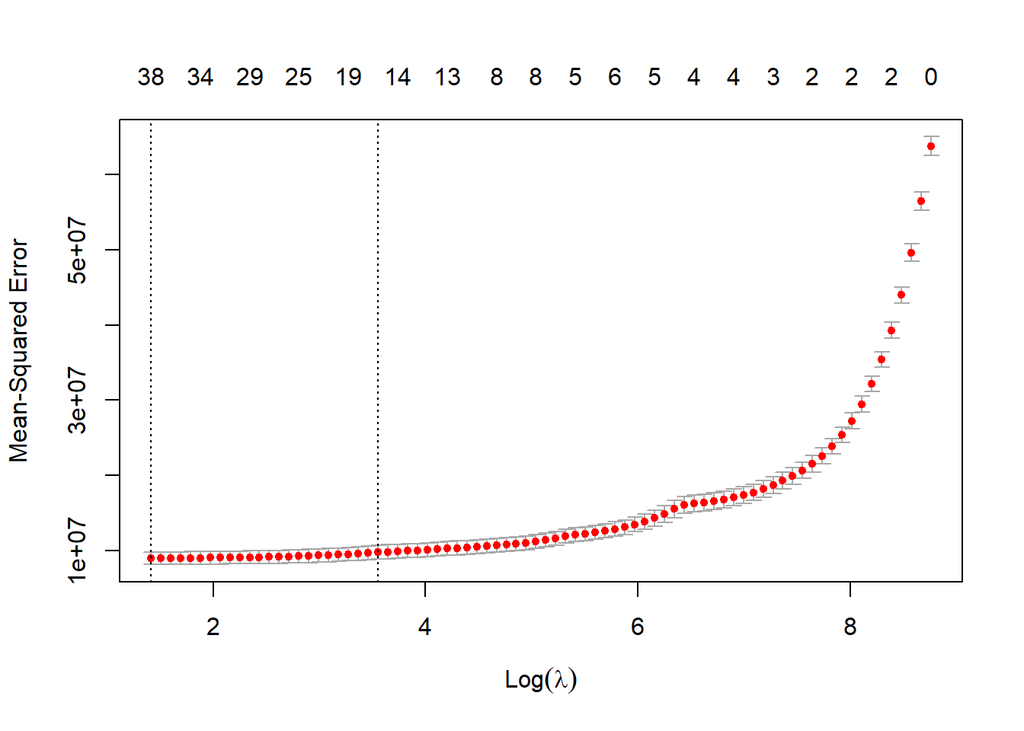

```r
plot(cvfit_0)
```

Coefficients resulting from using 34.92 as lambda value can be found below. Intercept and the 2 day lagged feature has the largest impact among selected features.

```r
coef(cvfit_0,s="lambda.1se")
```

```
## 49 x 1 sparse Matrix of class "dgCMatrix"
##                         1
## (Intercept)  1.858196e+03
## day_2_h_0    1.029362e+00
## day_2_h_1    7.039281e-02
## day_2_h_2    .
## day_2_h_3    9.032498e-02
## day_2_h_4    .
## day_2_h_5   -5.228987e-02
## day_2_h_6    .
## day_2_h_7    .
## day_2_h_8    .
## day_2_h_9    .
## day_2_h_10   .
## day_2_h_11   3.880196e-02
## day_2_h_12   .
## day_2_h_13  -1.134659e-02
## day_2_h_14   .
## day_2_h_15  -3.127028e-01
## day_2_h_16   .
## day_2_h_17   .
## day_2_h_18   3.273807e-03
## day_2_h_19   .
## day_2_h_20   .
## day_2_h_21   .
## day_2_h_22   .
## day_2_h_23  -6.867488e-02
## day_7_h_0    2.034365e-01
## day_7_h_1    .
## day_7_h_2    .
## day_7_h_3    .
## day_7_h_4   -8.278006e-03
## day_7_h_5   -1.152902e-01
## day_7_h_6    .
## day_7_h_7    9.756823e-02
## day_7_h_8    .
## day_7_h_9    .
## day_7_h_10   .
## day_7_h_11   .
## day_7_h_12   .
## day_7_h_13   .
## day_7_h_14   .
## day_7_h_15   .
## day_7_h_16   2.292146e-01
## day_7_h_17   6.681319e-02
## day_7_h_18   .
## day_7_h_19  -1.288465e-01
## day_7_h_20   .
## day_7_h_21   .
## day_7_h_22   .
## day_7_h_23  -2.867462e-01
```

```r
prediction_df4_0<-predict(cvfit_0,newx = as.matrix(test_df4_0[,-c(1:4)],s=cvfit_0$lambda.1se))
ae_t4_0<-abs(prediction_df4_0/test_df4_0$consumption)
```

### Model for 01:00

```r
train_df4_1<-filter(train_df_4, Saat=="01:00")
test_df4_1<-filter(test_df_4, Saat=="01:00")
cvfit_1=cv.glmnet(as.matrix(train_df4_1[,-c(1:4)]),train_df4_1$consumption,family='gaussian',nfolds=10,set.seed(1))
cvfit_1
```

```
##
## Call:  cv.glmnet(x = as.matrix(train_df4_1[, -c(1:4)]), y = train_df4_1$consumption,      weights = set.seed(1), nfolds = 10, family = "gaussian")
##
## Measure: Mean-Squared Error
##
##     Lambda Measure     SE Nonzero
## min  2.895 7556924 431851      37
## 1se 22.415 7950607 458342      21
```

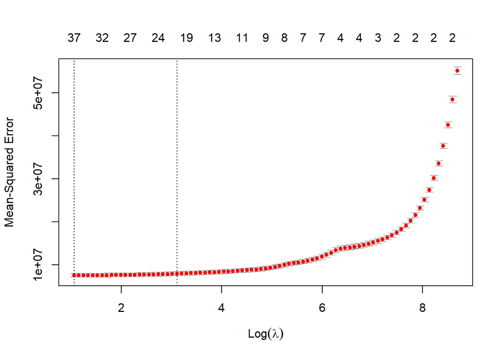

```r
plot(cvfit_1)
```

```r
coef(cvfit_1,s="lambda.1se")
```

```
## 49 x 1 sparse Matrix of class "dgCMatrix"
##                         1
## (Intercept)  1.727388e+03
## day_2_h_0    7.021949e-01
## day_2_h_1    2.939601e-01
## day_2_h_2    5.690670e-02
## day_2_h_3    .
## day_2_h_4    1.377435e-01
## day_2_h_5    .
## day_2_h_6   -4.740111e-02
## day_2_h_7    .
## day_2_h_8    .
## day_2_h_9   -2.579827e-02
## day_2_h_10   .
## day_2_h_11   .
## day_2_h_12   8.265068e-02
## day_2_h_13   .
## day_2_h_14  -3.218744e-02
## day_2_h_15   .
## day_2_h_16  -3.006744e-01
## day_2_h_17  -1.876351e-03
## day_2_h_18   .
## day_2_h_19   .
## day_2_h_20   .
## day_2_h_21   .
## day_2_h_22   .
## day_2_h_23  -1.086784e-01
## day_7_h_0    3.524168e-01
## day_7_h_1    .
## day_7_h_2    .
## day_7_h_3    .
## day_7_h_4    .
## day_7_h_5   -8.179724e-02
## day_7_h_6   -9.999339e-02
## day_7_h_7    .
## day_7_h_8    9.801204e-02
## day_7_h_9    .
## day_7_h_10   .
## day_7_h_11   .
## day_7_h_12  -2.030380e-02
## day_7_h_13  -1.795604e-03
## day_7_h_14   .
## day_7_h_15   .
## day_7_h_16   .
## day_7_h_17   2.214978e-01
## day_7_h_18   3.691199e-02
## day_7_h_19   .
## day_7_h_20  -5.531810e-02
## day_7_h_21   .
## day_7_h_22   .
## day_7_h_23  -4.027418e-01
```

```r
prediction_df4_1<-predict(cvfit_1,newx = as.matrix(test_df4_1[,-c(1:4)],s=cvfit_1$lambda.1se))
ae_t4_1<-abs(prediction_df4_1/test_df4_1$consumption)
```

### Model for 02:00

```r
train_df4_2<-filter(train_df_4, Saat=="02:00")
test_df4_2<-filter(test_df_4, Saat=="02:00")
cvfit_2=cv.glmnet(as.matrix(train_df4_2[,-c(1:4)]),train_df4_2$consumption,family='gaussian',nfolds=10,set.seed(1))
cvfit_2
```

```
##
## Call:  cv.glmnet(x = as.matrix(train_df4_2[, -c(1:4)]), y = train_df4_2$consumption,      weights = set.seed(1), nfolds = 10, family = "gaussian")
##
## Measure: Mean-Squared Error
##
##     Lambda Measure     SE Nonzero
## min  0.536 6094161 337756      45
## 1se 16.765 6415686 386745      23
```

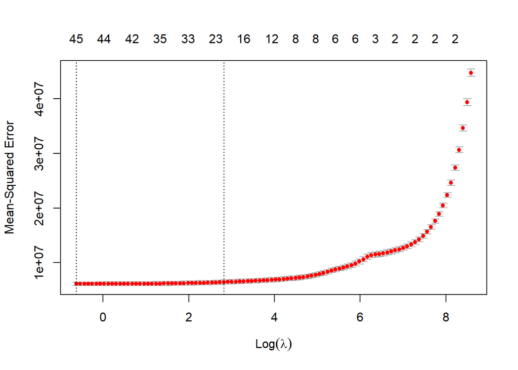

```r
plot(cvfit_2)
```

```r
coef(cvfit_2,s="lambda.1se")
```

```
## 49 x 1 sparse Matrix of class "dgCMatrix"
##                         1
## (Intercept)  1.156708e+03
## day_2_h_0    7.015272e-01
## day_2_h_1    .
## day_2_h_2    2.797563e-01
## day_2_h_3    1.956746e-02
## day_2_h_4    .
## day_2_h_5    1.189954e-01
## day_2_h_6    .
## day_2_h_7    .
## day_2_h_8    .
## day_2_h_9    .
## day_2_h_10  -6.910955e-02
## day_2_h_11  -1.359845e-02
## day_2_h_12   .
## day_2_h_13   8.288309e-02
## day_2_h_14   .
## day_2_h_15   .
## day_2_h_16   .
## day_2_h_17  -1.945686e-01
## day_2_h_18  -9.107947e-02
## day_2_h_19   .
## day_2_h_20   2.531993e-02
## day_2_h_21   8.684935e-04
## day_2_h_22   .
## day_2_h_23  -1.215348e-01
## day_7_h_0    3.900888e-01
## day_7_h_1    .
## day_7_h_2    .
## day_7_h_3    .
## day_7_h_4    .
## day_7_h_5    .
## day_7_h_6   -3.287515e-03
## day_7_h_7   -1.836948e-01
## day_7_h_8    .
## day_7_h_9    1.132674e-01
## day_7_h_10   .
## day_7_h_11   .
## day_7_h_12   .
## day_7_h_13  -3.791368e-05
## day_7_h_14  -2.476632e-02
## day_7_h_15  -2.060109e-02
## day_7_h_16   .
## day_7_h_17   .
## day_7_h_18   2.042394e-01
## day_7_h_19   5.148251e-02
## day_7_h_20   .
## day_7_h_21  -5.483220e-02
## day_7_h_22   .
## day_7_h_23  -4.148692e-01
```

```r
prediction_df4_2<-predict(cvfit_2,newx = as.matrix(test_df4_2[,-c(1:4)],s=cvfit_2$lambda.1se))
ae_t4_2<-abs(prediction_df4_2/test_df4_2$consumption)
```

### Model for 03:00

```r
train_df4_3<-filter(train_df_4, Saat=="03:00")
test_df4_3<-filter(test_df_4, Saat=="03:00")
cvfit_3=cv.glmnet(as.matrix(train_df4_3[,-c(1:4)]),train_df4_3$consumption,family='gaussian',nfolds=10,set.seed(1))
cvfit_3
```

```
##
## Call:  cv.glmnet(x = as.matrix(train_df4_3[, -c(1:4)]), y = train_df4_3$consumption,      weights = set.seed(1), nfolds = 10, family = "gaussian")
##
## Measure: Mean-Squared Error
##
##     Lambda Measure     SE Nonzero
## min   0.49 4971948 332996      47
## 1se  18.45 5298873 367298      17
```

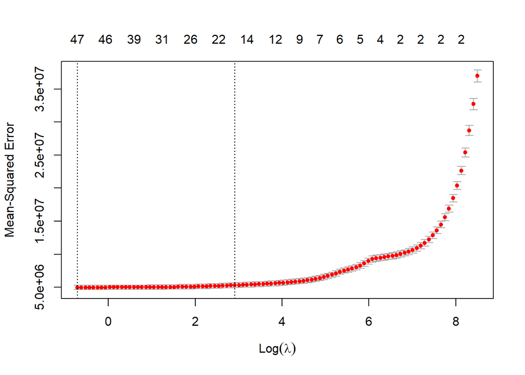

```r
plot(cvfit_3)
```

```r
coef(cvfit_3,s="lambda.1se")
```

```
## 49 x 1 sparse Matrix of class "dgCMatrix"
##                         1
## (Intercept) 706.690374051
## day_2_h_0     0.764522462
## day_2_h_1     .
## day_2_h_2     .
## day_2_h_3     0.180778382
## day_2_h_4     .
## day_2_h_5     .
## day_2_h_6     0.046623537
## day_2_h_7     0.094505432
## day_2_h_8     .
## day_2_h_9     .
## day_2_h_10    .
## day_2_h_11   -0.066790492
## day_2_h_12    .
## day_2_h_13    .
## day_2_h_14    0.027738349
## day_2_h_15    .
## day_2_h_16    .
## day_2_h_17    .
## day_2_h_18   -0.070570054
## day_2_h_19   -0.172775231
## day_2_h_20    .
## day_2_h_21    .
## day_2_h_22    .
## day_2_h_23   -0.048914883
## day_7_h_0     0.438622863
## day_7_h_1     .
## day_7_h_2     .
## day_7_h_3     .
## day_7_h_4     .
## day_7_h_5     .
## day_7_h_6     .
## day_7_h_7     .
## day_7_h_8    -0.170999220
## day_7_h_9     .
## day_7_h_10    0.096480832
## day_7_h_11    .
## day_7_h_12    .
## day_7_h_13    .
## day_7_h_14    .
## day_7_h_15   -0.003078897
## day_7_h_16   -0.013249120
## day_7_h_17    .
## day_7_h_18    .
## day_7_h_19    0.135128508
## day_7_h_20    0.123386473
## day_7_h_21    .
## day_7_h_22    .
## day_7_h_23   -0.520999632
```

```r
prediction_df4_3<-predict(cvfit_3,newx = as.matrix(test_df4_3[,-c(1:4)],s=cvfit_3$lambda.1se))
ae_t4_3<-abs(prediction_df4_3/test_df4_3$consumption)
```

### Model for 04:00

```r
train_df4_4<-filter(train_df_4, Saat=="04:00")
test_df4_4<-filter(test_df_4, Saat=="04:00")
cvfit_4=cv.glmnet(as.matrix(train_df4_4[,-c(1:4)]),train_df4_4$consumption,family='gaussian',nfolds=10,set.seed(1))
cvfit_4
```

```
##
## Call:  cv.glmnet(x = as.matrix(train_df4_4[, -c(1:4)]), y = train_df4_4$consumption,      weights = set.seed(1), nfolds = 10, family = "gaussian")
##
## Measure: Mean-Squared Error
##
##     Lambda Measure     SE Nonzero
## min  0.506 4410611 264214      45
## 1se 19.051 4649790 296930      14
```

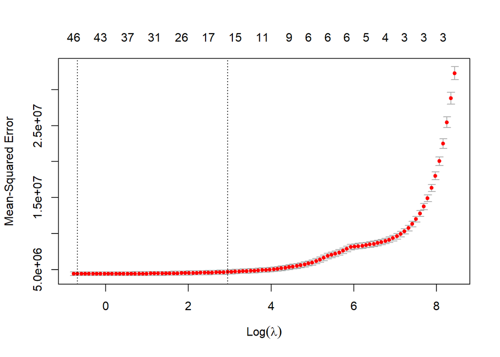

```r
plot(cvfit_4)
```

```r
coef(cvfit_4,s="lambda.1se")
```

```
## 49 x 1 sparse Matrix of class "dgCMatrix"
##                        1
## (Intercept) -18.47028167
## day_2_h_0     0.85675303
## day_2_h_1     .
## day_2_h_2     .
## day_2_h_3     .
## day_2_h_4     .
## day_2_h_5     .
## day_2_h_6     .
## day_2_h_7     .
## day_2_h_8     0.18717936
## day_2_h_9     .
## day_2_h_10    0.01895974
## day_2_h_11    .
## day_2_h_12   -0.05638097
## day_2_h_13   -0.03230013
## day_2_h_14    .
## day_2_h_15    0.03952718
## day_2_h_16    .
## day_2_h_17    .
## day_2_h_18    .
## day_2_h_19    .
## day_2_h_20   -0.23642078
## day_2_h_21    .
## day_2_h_22    .
## day_2_h_23    .
## day_7_h_0     0.43882916
## day_7_h_1     .
## day_7_h_2     .
## day_7_h_3     .
## day_7_h_4     .
## day_7_h_5     .
## day_7_h_6     .
## day_7_h_7     .
## day_7_h_8     .
## day_7_h_9    -0.11282819
## day_7_h_10    .
## day_7_h_11    0.05998823
## day_7_h_12    .
## day_7_h_13    .
## day_7_h_14    .
## day_7_h_15    .
## day_7_h_16    .
## day_7_h_17   -0.02497686
## day_7_h_18    .
## day_7_h_19    .
## day_7_h_20    0.12684879
## day_7_h_21    0.19023201
## day_7_h_22    .
## day_7_h_23   -0.59344093
```

```r
prediction_df4_4<-predict(cvfit_4,newx = as.matrix(test_df4_4[,-c(1:4)],s=cvfit_4$lambda.1se))
ae_t4_4<-abs(prediction_df4_4/test_df4_4$consumption)
```

### Model for 05:00

```r
train_df4_5<-filter(train_df_4, Saat=="05:00")
test_df4_5<-filter(test_df_4, Saat=="05:00")
cvfit_5=cv.glmnet(as.matrix(train_df4_5[,-c(1:4)]),train_df4_5$consumption,family='gaussian',nfolds=10,set.seed(1))
cvfit_5
```

```
##
## Call:  cv.glmnet(x = as.matrix(train_df4_5[, -c(1:4)]), y = train_df4_5$consumption,      weights = set.seed(1), nfolds = 10, family = "gaussian")
##
## Measure: Mean-Squared Error
##
##     Lambda Measure     SE Nonzero
## min  0.423 4175407 173609      44
## 1se 12.050 4341387 201301      24
```

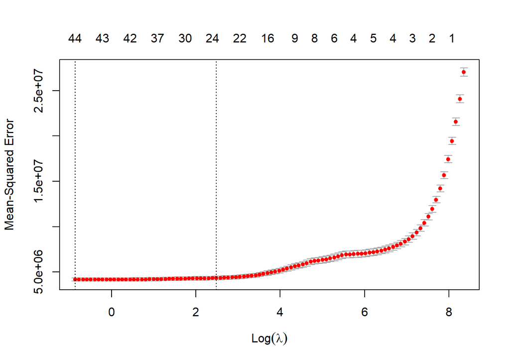

```r
plot(cvfit_5)
```

```r
coef(cvfit_5,s="lambda.1se")
```

```
## 49 x 1 sparse Matrix of class "dgCMatrix"
##                         1
## (Intercept) 280.124865506
## day_2_h_0     0.689054403
## day_2_h_1     .
## day_2_h_2     .
## day_2_h_3     .
## day_2_h_4     .
## day_2_h_5     0.066816888
## day_2_h_6     0.029653139
## day_2_h_7     .
## day_2_h_8     0.078324340
## day_2_h_9     0.064708067
## day_2_h_10    .
## day_2_h_11    0.089248740
## day_2_h_12    .
## day_2_h_13   -0.192571418
## day_2_h_14   -0.021305218
## day_2_h_15    .
## day_2_h_16    0.022090119
## day_2_h_17    0.122281275
## day_2_h_18    .
## day_2_h_19    .
## day_2_h_20    .
## day_2_h_21   -0.236337463
## day_2_h_22    .
## day_2_h_23    0.001160806
## day_7_h_0     0.501968254
## day_7_h_1     .
## day_7_h_2    -0.060323509
## day_7_h_3     .
## day_7_h_4     .
## day_7_h_5    -0.059812564
## day_7_h_6     .
## day_7_h_7     .
## day_7_h_8     .
## day_7_h_9    -0.061452022
## day_7_h_10   -0.061388499
## day_7_h_11    .
## day_7_h_12    0.130359301
## day_7_h_13    .
## day_7_h_14    .
## day_7_h_15    .
## day_7_h_16   -0.008285931
## day_7_h_17   -0.002851013
## day_7_h_18   -0.146774925
## day_7_h_19    .
## day_7_h_20    .
## day_7_h_21    0.266328661
## day_7_h_22    0.193000086
## day_7_h_23   -0.598563897
```

```r
prediction_df4_5<-predict(cvfit_5,newx = as.matrix(test_df4_5[,-c(1:4)],s=cvfit_5$lambda.1se))
ae_t4_5<-abs(prediction_df4_5/test_df4_5$consumption)
```

### Model for 06:00

```r
train_df4_6<-filter(train_df_4, Saat=="06:00")
test_df4_6<-filter(test_df_4, Saat=="06:00")
cvfit_6=cv.glmnet(as.matrix(train_df4_6[,-c(1:4)]),train_df4_6$consumption,family='gaussian',nfolds=10,set.seed(1))
cvfit_6
```

```
##
## Call:  cv.glmnet(x = as.matrix(train_df4_6[, -c(1:4)]), y = train_df4_6$consumption,      weights = set.seed(1), nfolds = 10, family = "gaussian")
##
## Measure: Mean-Squared Error
##
##     Lambda Measure     SE Nonzero
## min  1.301 4334981 215301      37
## 1se 10.077 4543581 234488      23
```

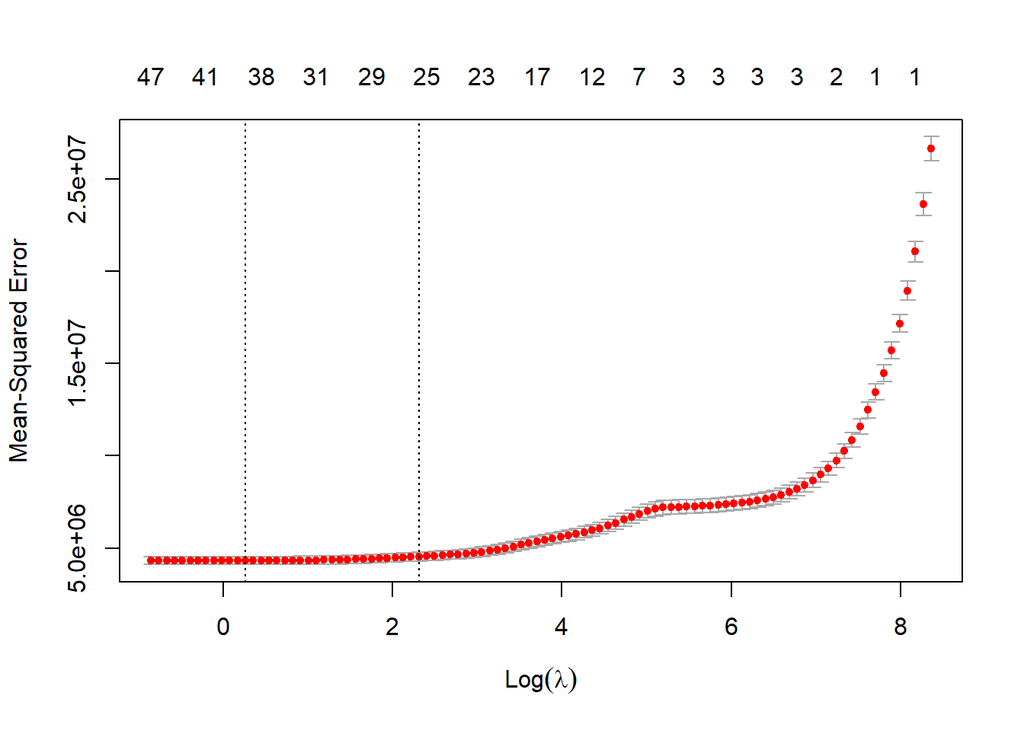

```r
plot(cvfit_6)
```

```r
coef(cvfit_6,s="lambda.1se")
```

```
## 49 x 1 sparse Matrix of class "dgCMatrix"
##                         1
## (Intercept) 654.103253854
## day_2_h_0     0.155976482
## day_2_h_1     0.149200781
## day_2_h_2     0.302458066
## day_2_h_3     .
## day_2_h_4     .
## day_2_h_5     .
## day_2_h_6     .
## day_2_h_7     .
## day_2_h_8     .
## day_2_h_9     .
## day_2_h_10    0.190684133
## day_2_h_11    .
## day_2_h_12    0.112237146
## day_2_h_13   -0.043119779
## day_2_h_14   -0.241646772
## day_2_h_15    .
## day_2_h_16    .
## day_2_h_17    0.114294803
## day_2_h_18    0.079389971
## day_2_h_19    .
## day_2_h_20    .
## day_2_h_21    .
## day_2_h_22   -0.215054648
## day_2_h_23    0.007825685
## day_7_h_0     1.177693744
## day_7_h_1    -0.583566177
## day_7_h_2     .
## day_7_h_3     .
## day_7_h_4     .
## day_7_h_5     .
## day_7_h_6    -0.079644917
## day_7_h_7     .
## day_7_h_8     .
## day_7_h_9     .
## day_7_h_10   -0.063165898
## day_7_h_11   -0.189979084
## day_7_h_12    .
## day_7_h_13    0.167921323
## day_7_h_14    0.081999575
## day_7_h_15    .
## day_7_h_16    .
## day_7_h_17   -0.036817570
## day_7_h_18   -0.029246746
## day_7_h_19   -0.078837407
## day_7_h_20    .
## day_7_h_21    .
## day_7_h_22    0.218365960
## day_7_h_23   -0.253487246
```

```r
prediction_df4_6<-predict(cvfit_6,newx = as.matrix(test_df4_6[,-c(1:4)],s=cvfit_6$lambda.1s))
ae_t4_6<-abs(prediction_df4_6/test_df4_6$consumption)
```

### Model for 07:00

```r
train_df4_7<-filter(train_df_4, Saat=="07:00")
test_df4_7<-filter(test_df_4, Saat=="07:00")
cvfit_7=cv.glmnet(as.matrix(train_df4_7[,-c(1:4)]),train_df4_7$consumption,family='gaussian',nfolds=10,set.seed(1))
cvfit_7
```

```
##
## Call:  cv.glmnet(x = as.matrix(train_df4_7[, -c(1:4)]), y = train_df4_7$consumption,      weights = set.seed(1), nfolds = 10, family = "gaussian")
##
## Measure: Mean-Squared Error
##
##     Lambda Measure     SE Nonzero
## min  0.558 8243164 475872      45
## 1se 21.002 8700904 561023      19
```

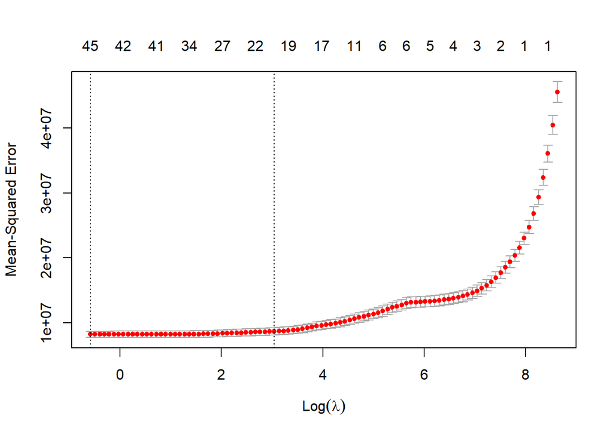

```r
plot(cvfit_7)
```

```r
coef(cvfit_7,s="lambda.1se")
```

```
## 49 x 1 sparse Matrix of class "dgCMatrix"
##                         1
## (Intercept)  1.138492e+03
## day_2_h_0    .
## day_2_h_1    .
## day_2_h_2    2.282364e-01
## day_2_h_3    4.025988e-01
## day_2_h_4    .
## day_2_h_5    .
## day_2_h_6    .
## day_2_h_7    2.533931e-02
## day_2_h_8    .
## day_2_h_9    .
## day_2_h_10   .
## day_2_h_11   3.202866e-01
## day_2_h_12   .
## day_2_h_13   1.449008e-02
## day_2_h_14   .
## day_2_h_15  -2.445529e-01
## day_2_h_16   .
## day_2_h_17   .
## day_2_h_18   1.727129e-01
## day_2_h_19   .
## day_2_h_20   .
## day_2_h_21   .
## day_2_h_22   .
## day_2_h_23  -2.434234e-01
## day_7_h_0    1.078031e+00
## day_7_h_1    .
## day_7_h_2   -5.529688e-01
## day_7_h_3    .
## day_7_h_4    .
## day_7_h_5   -5.417038e-02
## day_7_h_6    .
## day_7_h_7   -1.335156e-01
## day_7_h_8    .
## day_7_h_9    .
## day_7_h_10   .
## day_7_h_11  -2.565619e-01
## day_7_h_12  -1.078072e-01
## day_7_h_13   .
## day_7_h_14   2.844924e-01
## day_7_h_15   7.303602e-03
## day_7_h_16   .
## day_7_h_17   .
## day_7_h_18  -7.460819e-03
## day_7_h_19  -8.470568e-02
## day_7_h_20   .
## day_7_h_21   .
## day_7_h_22   .
## day_7_h_23   8.867424e-02
```

```r
prediction_df4_7<-predict(cvfit_7,newx = as.matrix(test_df4_7[,-c(1:4)],s=cvfit_7$lambda.1s))
ae_t4_7<-abs(prediction_df4_7/test_df4_7$consumption)
```

### Model for 08:00

```r
train_df4_8<-filter(train_df_4, Saat=="08:00")
test_df4_8<-filter(test_df_4, Saat=="08:00")
cvfit_8=cv.glmnet(as.matrix(train_df4_8[,-c(1:4)]),train_df4_8$consumption,family='gaussian',nfolds=10,set.seed(1))
cvfit_8
```

```
##
## Call:  cv.glmnet(x = as.matrix(train_df4_8[, -c(1:4)]), y = train_df4_8$consumption,      weights = set.seed(1), nfolds = 10, family = "gaussian")
##
## Measure: Mean-Squared Error
##
##     Lambda  Measure      SE Nonzero
## min   1.03 25512730 2066795      47
## 1se  42.69 27528380 2433096      17
```

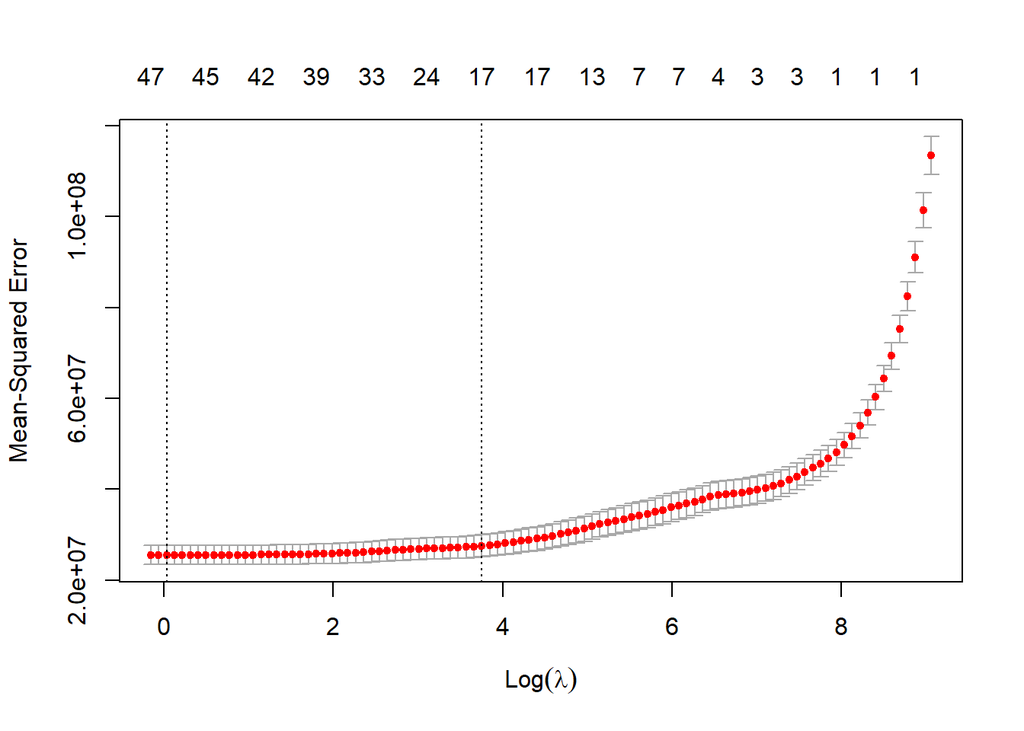

```r
plot(cvfit_8)
```

```r
coef(cvfit_8,s="lambda.1se")
```

```
## 49 x 1 sparse Matrix of class "dgCMatrix"
##                         1
## (Intercept) 6513.04794586
## day_2_h_0      .
## day_2_h_1      .
## day_2_h_2      .
## day_2_h_3      .
## day_2_h_4      0.65835905
## day_2_h_5      .
## day_2_h_6      .
## day_2_h_7      .
## day_2_h_8      0.07486099
## day_2_h_9      .
## day_2_h_10     .
## day_2_h_11     .
## day_2_h_12     0.41500312
## day_2_h_13     .
## day_2_h_14     .
## day_2_h_15     .
## day_2_h_16    -0.20640159
## day_2_h_17     .
## day_2_h_18     .
## day_2_h_19     0.23543675
## day_2_h_20     .
## day_2_h_21     .
## day_2_h_22     .
## day_2_h_23    -0.33066441
## day_7_h_0      0.67549038
## day_7_h_1      0.64348796
## day_7_h_2      .
## day_7_h_3      .
## day_7_h_4     -0.65765015
## day_7_h_5      .
## day_7_h_6      .
## day_7_h_7      .
## day_7_h_8     -0.17549349
## day_7_h_9      .
## day_7_h_10     .
## day_7_h_11     .
## day_7_h_12    -0.33367387
## day_7_h_13    -0.35070100
## day_7_h_14     .
## day_7_h_15     0.27385330
## day_7_h_16     0.13995000
## day_7_h_17     .
## day_7_h_18     .
## day_7_h_19    -0.05636046
## day_7_h_20    -0.08523424
## day_7_h_21     .
## day_7_h_22     .
## day_7_h_23     0.10211840
```

```r
prediction_df4_8<-predict(cvfit_8,newx = as.matrix(test_df4_8[,-c(1:4)],s=cvfit_8$lambda.1s))
ae_t4_8<-abs(prediction_df4_8/test_df4_8$consumption)
```

### Model for 09:00

```r
train_df4_9<-filter(train_df_4, Saat=="09:00")
test_df4_9<-filter(test_df_4, Saat=="09:00")
cvfit_9=cv.glmnet(as.matrix(train_df4_9[,-c(1:4)]),train_df4_9$consumption,family='gaussian',nfolds=10,set.seed(1))
cvfit_9
```

```
##
## Call:  cv.glmnet(x = as.matrix(train_df4_9[, -c(1:4)]), y = train_df4_9$consumption,      weights = set.seed(1), nfolds = 10, family = "gaussian")
##
## Measure: Mean-Squared Error
##
##     Lambda  Measure      SE Nonzero
## min   1.11 35828404 2871619      44
## 1se  34.82 38569550 3444415      21
```

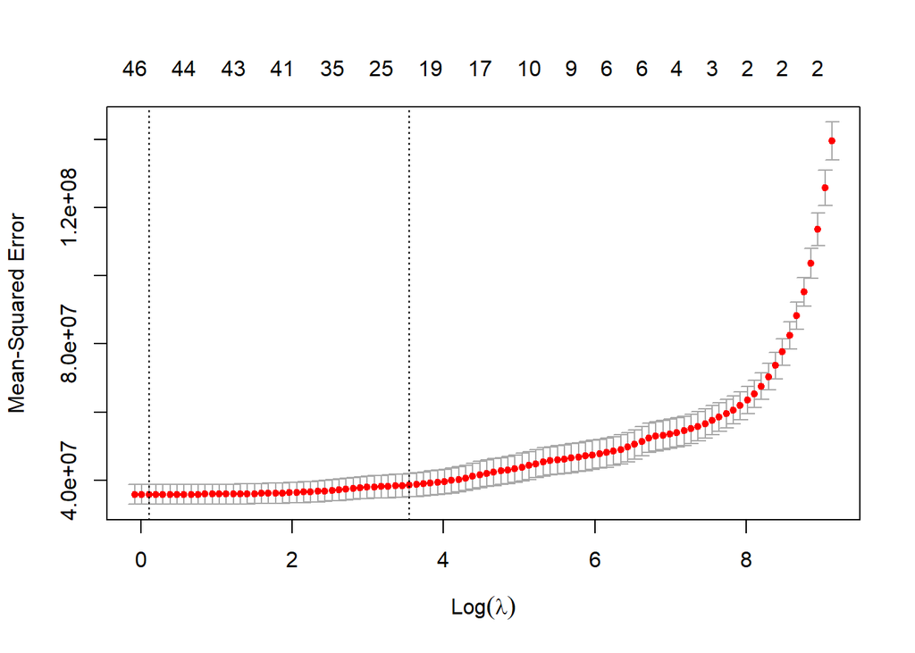

```r
plot(cvfit_9)
```

```r
coef(cvfit_9,s="lambda.1se")
```

```
## 49 x 1 sparse Matrix of class "dgCMatrix"
##                         1
## (Intercept)  1.026957e+04
## day_2_h_0    1.346195e-01
## day_2_h_1    .
## day_2_h_2   -1.972248e-01
## day_2_h_3    .
## day_2_h_4    2.533695e-03
## day_2_h_5    5.863366e-01
## day_2_h_6    .
## day_2_h_7    .
## day_2_h_8    .
## day_2_h_9    8.646172e-02
## day_2_h_10   .
## day_2_h_11   .
## day_2_h_12   .
## day_2_h_13   4.837061e-01
## day_2_h_14   .
## day_2_h_15   .
## day_2_h_16  -5.034201e-02
## day_2_h_17  -4.389607e-01
## day_2_h_18   .
## day_2_h_19   .
## day_2_h_20   3.949916e-01
## day_2_h_21   8.739392e-03
## day_2_h_22   .
## day_2_h_23  -2.321782e-01
## day_7_h_0    3.663554e-01
## day_7_h_1    3.527759e-01
## day_7_h_2    6.872624e-01
## day_7_h_3    .
## day_7_h_4    .
## day_7_h_5   -6.297057e-01
## day_7_h_6    .
## day_7_h_7    .
## day_7_h_8    .
## day_7_h_9   -1.785012e-01
## day_7_h_10   .
## day_7_h_11   .
## day_7_h_12   .
## day_7_h_13  -4.267576e-01
## day_7_h_14  -4.804386e-01
## day_7_h_15   .
## day_7_h_16   3.421045e-01
## day_7_h_17   4.141028e-01
## day_7_h_18   .
## day_7_h_19   .
## day_7_h_20  -2.887245e-01
## day_7_h_21   .
## day_7_h_22   .
## day_7_h_23   .
```

```r
prediction_df4_9<-predict(cvfit_9,newx = as.matrix(test_df4_9[,-c(1:4)],s=cvfit_9$lambda.1s))
ae_t4_9<-abs(prediction_df4_9/test_df4_9$consumption)
```

### Model for 10:00

```r
train_df4_10<-filter(train_df_4, Saat=="10:00")
test_df4_10<-filter(test_df_4, Saat=="10:00")
cvfit_10=cv.glmnet(as.matrix(train_df4_10[,-c(1:4)]),train_df4_10$consumption,family='gaussian',nfolds=10,set.seed(1))
cvfit_10
```

```
##
## Call:  cv.glmnet(x = as.matrix(train_df4_10[, -c(1:4)]), y = train_df4_10$consumption,      weights = set.seed(1), nfolds = 10, family = "gaussian")
##
## Measure: Mean-Squared Error
##
##     Lambda  Measure      SE Nonzero
## min   0.97 35660571 2842262      45
## 1se  33.16 38495541 3505584      20
```

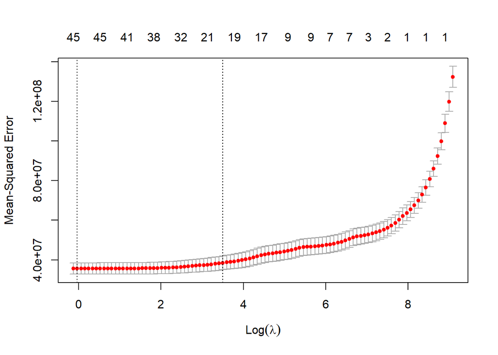

```r
plot(cvfit_10)
```

```r
coef(cvfit_10,s="lambda.1se")
```

```
## 49 x 1 sparse Matrix of class "dgCMatrix"
##                         1
## (Intercept)  1.062833e+04
## day_2_h_0    6.136834e-01
## day_2_h_1   -1.998898e-01
## day_2_h_2   -3.363011e-01
## day_2_h_3    .
## day_2_h_4    .
## day_2_h_5    .
## day_2_h_6    5.906063e-01
## day_2_h_7    .
## day_2_h_8    .
## day_2_h_9    .
## day_2_h_10   .
## day_2_h_11   .
## day_2_h_12   .
## day_2_h_13   .
## day_2_h_14   4.534650e-01
## day_2_h_15   .
## day_2_h_16   .
## day_2_h_17   .
## day_2_h_18  -5.602732e-01
## day_2_h_19   .
## day_2_h_20   .
## day_2_h_21   3.448278e-01
## day_2_h_22   1.212518e-05
## day_2_h_23  -9.203903e-02
## day_7_h_0    .
## day_7_h_1    3.684068e-01
## day_7_h_2    4.461396e-01
## day_7_h_3    .
## day_7_h_4    5.666654e-01
## day_7_h_5   -1.866757e-01
## day_7_h_6   -4.831666e-01
## day_7_h_7    .
## day_7_h_8    .
## day_7_h_9    .
## day_7_h_10  -7.875629e-02
## day_7_h_11   .
## day_7_h_12   .
## day_7_h_13   .
## day_7_h_14  -3.660422e-01
## day_7_h_15  -6.239388e-01
## day_7_h_16   .
## day_7_h_17   4.181582e-01
## day_7_h_18   4.171013e-01
## day_7_h_19   .
## day_7_h_20   .
## day_7_h_21  -2.978197e-01
## day_7_h_22   .
## day_7_h_23   .
```

```r
prediction_df4_10<-predict(cvfit_10,newx = as.matrix(test_df4_10[,-c(1:4)],s=cvfit_10$lambda.1s))
ae_t4_10<-abs(prediction_df4_10/test_df4_10$consumption)
```

### Model for 11:00

```r
train_df4_11<-filter(train_df_4, Saat=="11:00")
test_df4_11<-filter(test_df_4, Saat=="11:00")
cvfit_11=cv.glmnet(as.matrix(train_df4_11[,-c(1:4)]),train_df4_11$consumption,family='gaussian',nfolds=10,set.seed(1))
cvfit_11
```

```
##
## Call:  cv.glmnet(x = as.matrix(train_df4_11[, -c(1:4)]), y = train_df4_11$consumption,      weights = set.seed(1), nfolds = 10, family = "gaussian")
##
## Measure: Mean-Squared Error
##
##     Lambda  Measure      SE Nonzero
## min   1.77 35951752 2908583      43
## 1se  41.96 38634366 3515151      18
```

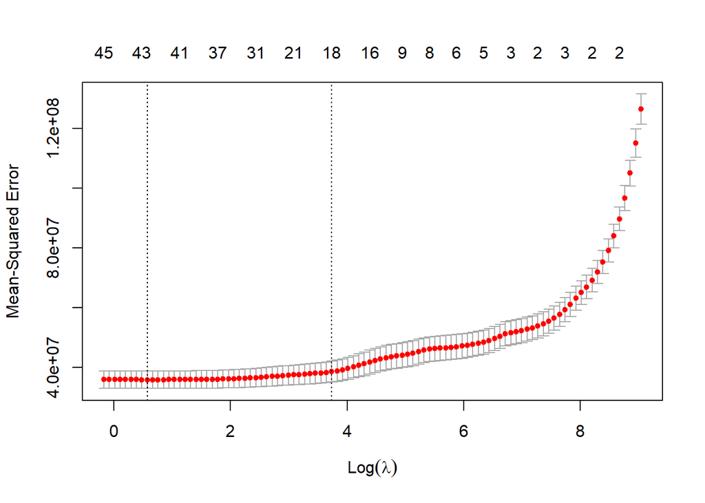

```r
plot(cvfit_11)
```

```r
coef(cvfit_11,s="lambda.1se")
```

```
## 49 x 1 sparse Matrix of class "dgCMatrix"
##                         1
## (Intercept)  1.128614e+04
## day_2_h_0    7.177864e-01
## day_2_h_1    .
## day_2_h_2   -4.584319e-01
## day_2_h_3   -1.133749e-01
## day_2_h_4    .
## day_2_h_5    .
## day_2_h_6    3.013913e-02
## day_2_h_7    5.062549e-01
## day_2_h_8    .
## day_2_h_9    .
## day_2_h_10   .
## day_2_h_11   .
## day_2_h_12   .
## day_2_h_13   .
## day_2_h_14   .
## day_2_h_15   3.858329e-01
## day_2_h_16   .
## day_2_h_17   .
## day_2_h_18   .
## day_2_h_19  -4.484044e-01
## day_2_h_20   .
## day_2_h_21   .
## day_2_h_22   1.612808e-01
## day_2_h_23   .
## day_7_h_0    .
## day_7_h_1    .
## day_7_h_2    5.705581e-01
## day_7_h_3    .
## day_7_h_4    5.212114e-01
## day_7_h_5    6.673094e-02
## day_7_h_6    .
## day_7_h_7   -4.567006e-01
## day_7_h_8    .
## day_7_h_9    .
## day_7_h_10   .
## day_7_h_11  -4.668010e-02
## day_7_h_12   .
## day_7_h_13   .
## day_7_h_14   .
## day_7_h_15  -3.142341e-01
## day_7_h_16  -6.229527e-01
## day_7_h_17   .
## day_7_h_18   3.636571e-01
## day_7_h_19   4.082400e-01
## day_7_h_20   .
## day_7_h_21   .
## day_7_h_22  -2.730503e-01
## day_7_h_23   .
```

```r
prediction_df4_11<-predict(cvfit_11,newx = as.matrix(test_df4_11[,-c(1:4)],s=cvfit_11$lambda.1s))
ae_t4_11<-abs(prediction_df4_11/test_df4_11$consumption)
```

### Model for 12:00

```r
train_df4_12<-filter(train_df_4, Saat=="12:00")
test_df4_12<-filter(test_df_4, Saat=="12:00")
cvfit_12=cv.glmnet(as.matrix(train_df4_12[,-c(1:4)]),train_df4_12$consumption,family='gaussian',nfolds=10,set.seed(1))
cvfit_12
```

```
##
## Call:  cv.glmnet(x = as.matrix(train_df4_12[, -c(1:4)]), y = train_df4_12$consumption,      weights = set.seed(1), nfolds = 10, family = "gaussian")
##
## Measure: Mean-Squared Error
##
##     Lambda  Measure      SE Nonzero
## min   2.04 31454784 2472816      46
## 1se  63.74 33906870 3029137      17
```

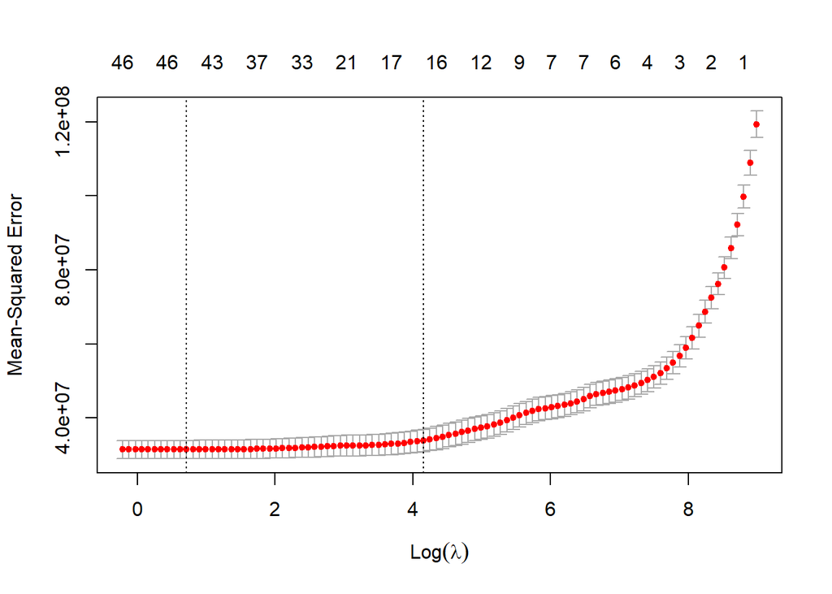

```r
plot(cvfit_12)
```

```r
coef(cvfit_12,s="lambda.1se")
```

```
## 49 x 1 sparse Matrix of class "dgCMatrix"
##                         1
## (Intercept)  8.475811e+03
## day_2_h_0    9.250678e-01
## day_2_h_1    .
## day_2_h_2    .
## day_2_h_3   -6.133792e-01
## day_2_h_4    .
## day_2_h_5    .
## day_2_h_6    .
## day_2_h_7    .
## day_2_h_8    2.531764e-01
## day_2_h_9    .
## day_2_h_10   .
## day_2_h_11   .
## day_2_h_12   .
## day_2_h_13   .
## day_2_h_14   .
## day_2_h_15   6.012270e-02
## day_2_h_16   2.357742e-01
## day_2_h_17   .
## day_2_h_18   .
## day_2_h_19   .
## day_2_h_20  -1.527582e-01
## day_2_h_21  -4.335023e-02
## day_2_h_22   .
## day_2_h_23   .
## day_7_h_0    .
## day_7_h_1    .
## day_7_h_2    1.153333e-01
## day_7_h_3    2.837841e-02
## day_7_h_4    4.878097e-01
## day_7_h_5    1.955455e-01
## day_7_h_6    .
## day_7_h_7    .
## day_7_h_8   -2.755622e-01
## day_7_h_9    .
## day_7_h_10   .
## day_7_h_11   .
## day_7_h_12   .
## day_7_h_13   .
## day_7_h_14   .
## day_7_h_15   .
## day_7_h_16  -2.017120e-01
## day_7_h_17  -5.020318e-01
## day_7_h_18   .
## day_7_h_19   4.151703e-01
## day_7_h_20   7.788637e-04
## day_7_h_21   .
## day_7_h_22   .
## day_7_h_23  -3.503080e-02
```

```r
prediction_df4_12<-predict(cvfit_12,newx = as.matrix(test_df4_12[,-c(1:4)],s=cvfit_12$lambda.1s))
ae_t4_12<-abs(prediction_df4_12/test_df4_12$consumption)
```

### Model for 13:00

```r
train_df4_13<-filter(train_df_4, Saat=="13:00")
test_df4_13<-filter(test_df_4, Saat=="13:00")
cvfit_13=cv.glmnet(as.matrix(train_df4_13[,-c(1:4)]),train_df4_13$consumption,family='gaussian',nfolds=10,set.seed(1))
cvfit_13
```

```
##
## Call:  cv.glmnet(x = as.matrix(train_df4_13[, -c(1:4)]), y = train_df4_13$consumption,      weights = set.seed(1), nfolds = 10, family = "gaussian")
##
## Measure: Mean-Squared Error
##
##     Lambda  Measure      SE Nonzero
## min   0.94 32333462 2409118      48
## 1se  61.74 34712175 2805110      21
```

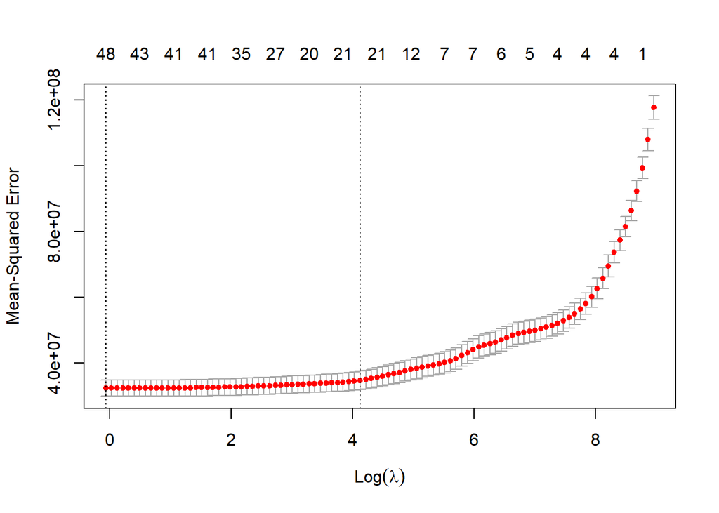

```r
plot(cvfit_13)
```

```r
coef(cvfit_13,s="lambda.1se")
```

```
## 49 x 1 sparse Matrix of class "dgCMatrix"
##                         1
## (Intercept) 9165.24822176
## day_2_h_0      1.04921563
## day_2_h_1      .
## day_2_h_2     -0.01307506
## day_2_h_3      .
## day_2_h_4     -0.76259090
## day_2_h_5      .
## day_2_h_6      0.10978429
## day_2_h_7      0.03846373
## day_2_h_8      0.11222583
## day_2_h_9      0.03871470
## day_2_h_10     .
## day_2_h_11     .
## day_2_h_12     .
## day_2_h_13     0.10033951
## day_2_h_14     .
## day_2_h_15     .
## day_2_h_16     0.02266849
## day_2_h_17     0.20016070
## day_2_h_18     .
## day_2_h_19     0.04897618
## day_2_h_20     .
## day_2_h_21    -0.18597490
## day_2_h_22    -0.05849844
## day_2_h_23     .
## day_7_h_0      0.12546594
## day_7_h_1      .
## day_7_h_2      .
## day_7_h_3      .
## day_7_h_4      0.13879109
## day_7_h_5      0.26073915
## day_7_h_6      0.27470841
## day_7_h_7      .
## day_7_h_8      .
## day_7_h_9     -0.32911362
## day_7_h_10     .
## day_7_h_11     .
## day_7_h_12     .
## day_7_h_13     .
## day_7_h_14     .
## day_7_h_15     .
## day_7_h_16     .
## day_7_h_17    -0.07973489
## day_7_h_18    -0.45045394
## day_7_h_19     .
## day_7_h_20     0.24688457
## day_7_h_21     .
## day_7_h_22     .
## day_7_h_23     .
```

```r
prediction_df4_13<-predict(cvfit_13,newx = as.matrix(test_df4_13[,-c(1:4)],s=cvfit_13$lambda.1s))
ae_t4_13<-abs(prediction_df4_13/test_df4_13$consumption)
```

### Model for 14:00

```r
train_df4_14<-filter(train_df_4, Saat=="14:00")
test_df4_14<-filter(test_df_4, Saat=="14:00")
cvfit_14=cv.glmnet(as.matrix(train_df4_14[,-c(1:4)]),train_df4_14$consumption,family='gaussian',nfolds=10,set.seed(1))
cvfit_14
```

```
##
## Call:  cv.glmnet(x = as.matrix(train_df4_14[, -c(1:4)]), y = train_df4_14$consumption,      weights = set.seed(1), nfolds = 10, family = "gaussian")
##
## Measure: Mean-Squared Error
##
##     Lambda  Measure      SE Nonzero
## min   2.39 34253633 2580914      42
## 1se  62.03 36757841 2967151      18
```

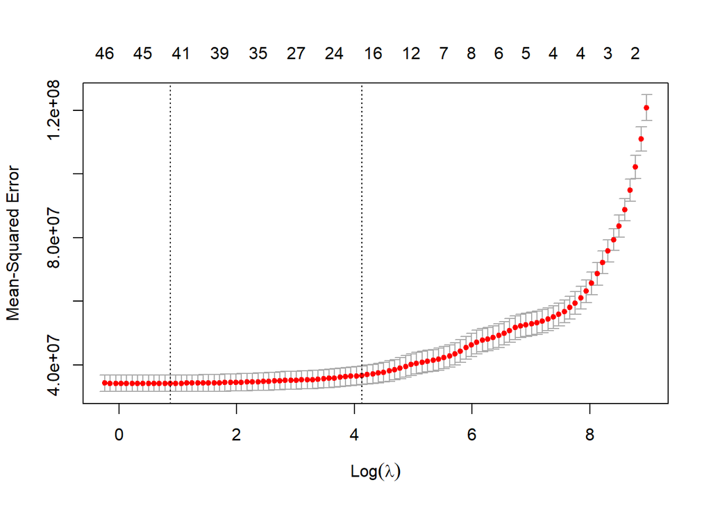

```r
plot(cvfit_14)
```

```r
coef(cvfit_14,s="lambda.1se")
```

```
## 49 x 1 sparse Matrix of class "dgCMatrix"
##                         1
## (Intercept)  1.093863e+04
## day_2_h_0    .
## day_2_h_1    1.082008e+00
## day_2_h_2    .
## day_2_h_3   -1.548627e-01
## day_2_h_4    .
## day_2_h_5   -6.355788e-01
## day_2_h_6    .
## day_2_h_7    .
## day_2_h_8    .
## day_2_h_9    3.795158e-02
## day_2_h_10   3.146899e-01
## day_2_h_11   .
## day_2_h_12   .
## day_2_h_13   .
## day_2_h_14   .
## day_2_h_15   .
## day_2_h_16   .
## day_2_h_17   2.170746e-01
## day_2_h_18   3.230728e-02
## day_2_h_19   .
## day_2_h_20   2.022506e-02
## day_2_h_21   .
## day_2_h_22   .
## day_2_h_23  -2.138906e-01
## day_7_h_0    5.997415e-02
## day_7_h_1    .
## day_7_h_2    .
## day_7_h_3    .
## day_7_h_4    .
## day_7_h_5    1.048595e-01
## day_7_h_6    4.909215e-01
## day_7_h_7    8.712421e-02
## day_7_h_8    .
## day_7_h_9    .
## day_7_h_10  -1.773969e-01
## day_7_h_11   .
## day_7_h_12   .
## day_7_h_13   .
## day_7_h_14  -2.198875e-01
## day_7_h_15   .
## day_7_h_16   .
## day_7_h_17   .
## day_7_h_18  -3.882488e-02
## day_7_h_19  -3.854108e-01
## day_7_h_20   .
## day_7_h_21   2.468801e-01
## day_7_h_22   .
## day_7_h_23   .
```

```r
prediction_df4_14<-predict(cvfit_14,newx = as.matrix(test_df4_14[,-c(1:4)],s=cvfit_14$lambda.1s))
ae_t4_14<-abs(prediction_df4_14/test_df4_14$consumption)
```

### Model for 15:00

```r
train_df4_15<-filter(train_df_4, Saat=="15:00")
test_df4_15<-filter(test_df_4, Saat=="15:00")
cvfit_15=cv.glmnet(as.matrix(train_df4_15[,-c(1:4)]),train_df4_15$consumption,family='gaussian',nfolds=10,set.seed(1))
cvfit_15
```

```
##
## Call:  cv.glmnet(x = as.matrix(train_df4_15[, -c(1:4)]), y = train_df4_15$consumption,      weights = set.seed(1), nfolds = 10, family = "gaussian")
##
## Measure: Mean-Squared Error
##
##     Lambda  Measure      SE Nonzero
## min   1.14 33163291 2665496      47
## 1se  51.87 35817567 2893840      21
```

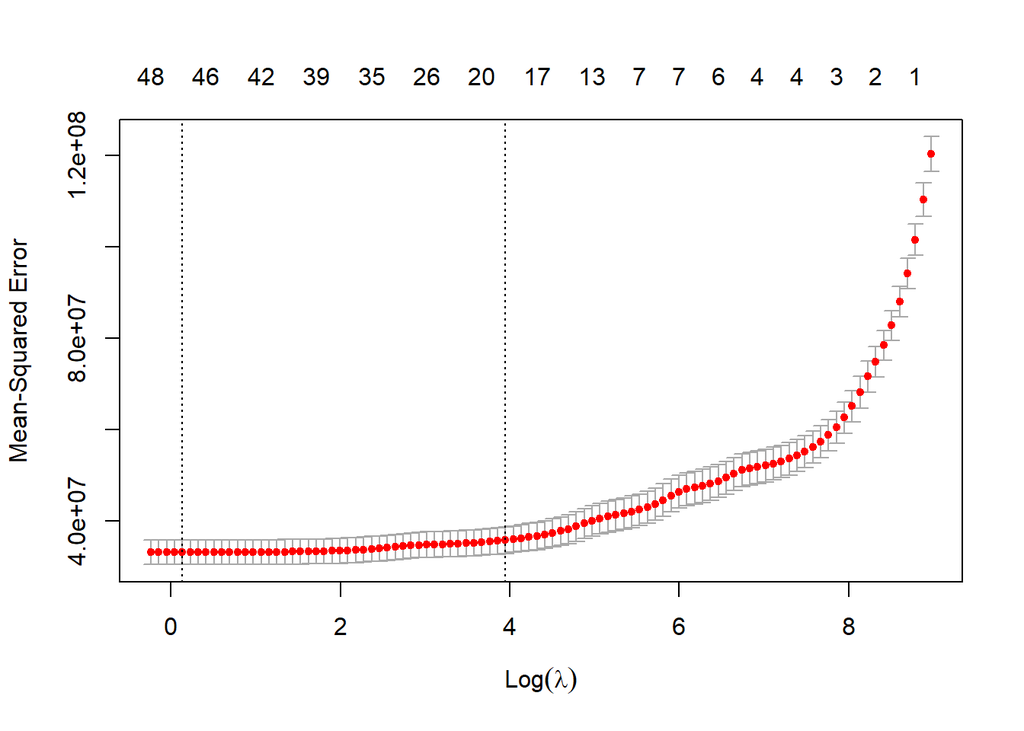

```r
plot(cvfit_15)
```

```r
coef(cvfit_15,s="lambda.1se")
```

```
## 49 x 1 sparse Matrix of class "dgCMatrix"
##                         1
## (Intercept)  1.065195e+04
## day_2_h_0    8.365617e-02
## day_2_h_1    .
## day_2_h_2    1.048709e+00
## day_2_h_3    .
## day_2_h_4   -3.004378e-01
## day_2_h_5    .
## day_2_h_6   -5.491463e-01
## day_2_h_7    .
## day_2_h_8    .
## day_2_h_9    .
## day_2_h_10   1.664445e-03
## day_2_h_11   3.600061e-01
## day_2_h_12   .
## day_2_h_13   .
## day_2_h_14   .
## day_2_h_15   .
## day_2_h_16   .
## day_2_h_17   .
## day_2_h_18   2.112870e-01
## day_2_h_19   6.251623e-02
## day_2_h_20   .
## day_2_h_21   1.144210e-01
## day_2_h_22   .
## day_2_h_23  -3.022753e-01
## day_7_h_0    2.321510e-01
## day_7_h_1    .
## day_7_h_2   -9.683299e-02
## day_7_h_3   -4.748435e-16
## day_7_h_4    .
## day_7_h_5    .
## day_7_h_6    .
## day_7_h_7    5.081403e-01
## day_7_h_8    1.569812e-01
## day_7_h_9    .
## day_7_h_10  -2.388472e-02
## day_7_h_11  -1.781327e-01
## day_7_h_12   .
## day_7_h_13   .
## day_7_h_14   .
## day_7_h_15  -2.423184e-01
## day_7_h_16   .
## day_7_h_17   .
## day_7_h_18   .
## day_7_h_19  -1.176165e-02
## day_7_h_20  -4.256226e-01
## day_7_h_21   .
## day_7_h_22   2.454458e-01
## day_7_h_23   .
```

```r
prediction_df4_15<-predict(cvfit_15,newx = as.matrix(test_df4_15[,-c(1:4)],s=cvfit_15$lambda.1s))
ae_t4_15<-abs(prediction_df4_15/test_df4_15$consumption)
```

### Model for 16:00

```r
train_df4_16<-filter(train_df_4, Saat=="16:00")
test_df4_16<-filter(test_df_4, Saat=="16:00")
cvfit_16=cv.glmnet(as.matrix(train_df4_16[,-c(1:4)]),train_df4_16$consumption,family='gaussian',nfolds=10,set.seed(1))
cvfit_16
```

```
##
## Call:  cv.glmnet(x = as.matrix(train_df4_16[, -c(1:4)]), y = train_df4_16$consumption,      weights = set.seed(1), nfolds = 10, family = "gaussian")
##
## Measure: Mean-Squared Error
##
##     Lambda  Measure      SE Nonzero
## min   0.87 30629610 2678716      44
## 1se  35.89 33173952 2962691      24
```

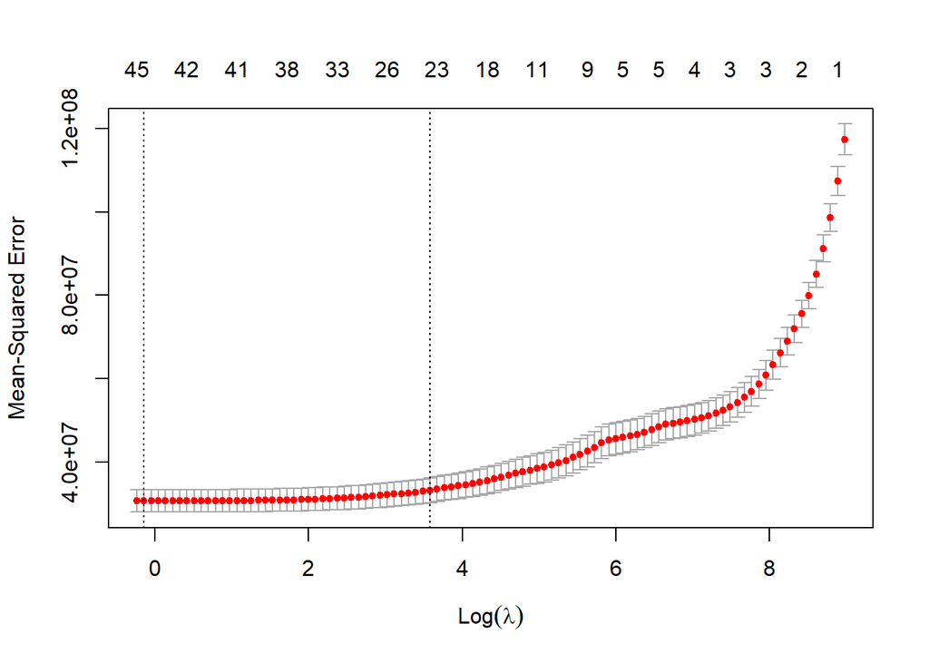

```r
plot(cvfit_16)
```

```r
coef(cvfit_16,s="lambda.1se")
```

```
## 49 x 1 sparse Matrix of class "dgCMatrix"
##                         1
## (Intercept)  1.140924e+04
## day_2_h_0    4.859728e-01
## day_2_h_1    .
## day_2_h_2   -2.145598e-01
## day_2_h_3    9.608510e-01
## day_2_h_4    .
## day_2_h_5   -4.186249e-01
## day_2_h_6    .
## day_2_h_7   -5.304590e-01
## day_2_h_8    .
## day_2_h_9    1.155351e-03
## day_2_h_10   2.412388e-02
## day_2_h_11   2.921157e-01
## day_2_h_12   1.574207e-01
## day_2_h_13   .
## day_2_h_14   .
## day_2_h_15   .
## day_2_h_16   .
## day_2_h_17   .
## day_2_h_18   .
## day_2_h_19   4.522335e-02
## day_2_h_20   2.327142e-01
## day_2_h_21   .
## day_2_h_22   1.244110e-01
## day_2_h_23  -3.460377e-01
## day_7_h_0    4.264302e-01
## day_7_h_1    .
## day_7_h_2    .
## day_7_h_3    .
## day_7_h_4   -3.020480e-01
## day_7_h_5    .
## day_7_h_6    .
## day_7_h_7    3.689898e-02
## day_7_h_8    4.380454e-01
## day_7_h_9    3.897842e-01
## day_7_h_10   .
## day_7_h_11  -7.244344e-02
## day_7_h_12  -4.931759e-01
## day_7_h_13   .
## day_7_h_14   .
## day_7_h_15   .
## day_7_h_16  -3.731436e-02
## day_7_h_17   .
## day_7_h_18   .
## day_7_h_19   .
## day_7_h_20  -1.397798e-01
## day_7_h_21  -4.598677e-01
## day_7_h_22   .
## day_7_h_23   2.847881e-01
```

```r
prediction_df4_16<-predict(cvfit_16,newx = as.matrix(test_df4_16[,-c(1:4)],s=cvfit_16$lambda.1s))
ae_t4_16<-abs(prediction_df4_16/test_df4_16$consumption)
```

### Model for 17:00

```r
train_df4_17<-filter(train_df_4, Saat=="17:00")
test_df4_17<-filter(test_df_4, Saat=="17:00")
cvfit_17=cv.glmnet(as.matrix(train_df4_17[,-c(1:4)]),train_df4_17$consumption,family='gaussian',nfolds=10,set.seed(1))
cvfit_17
```

```
##
## Call:  cv.glmnet(x = as.matrix(train_df4_17[, -c(1:4)]), y = train_df4_17$consumption,      weights = set.seed(1), nfolds = 10, family = "gaussian")
##
## Measure: Mean-Squared Error
##
##     Lambda Measure      SE Nonzero
## min   1.66 2.6e+07 2128696      43
## 1se  35.69 2.8e+07 2430952      22
```

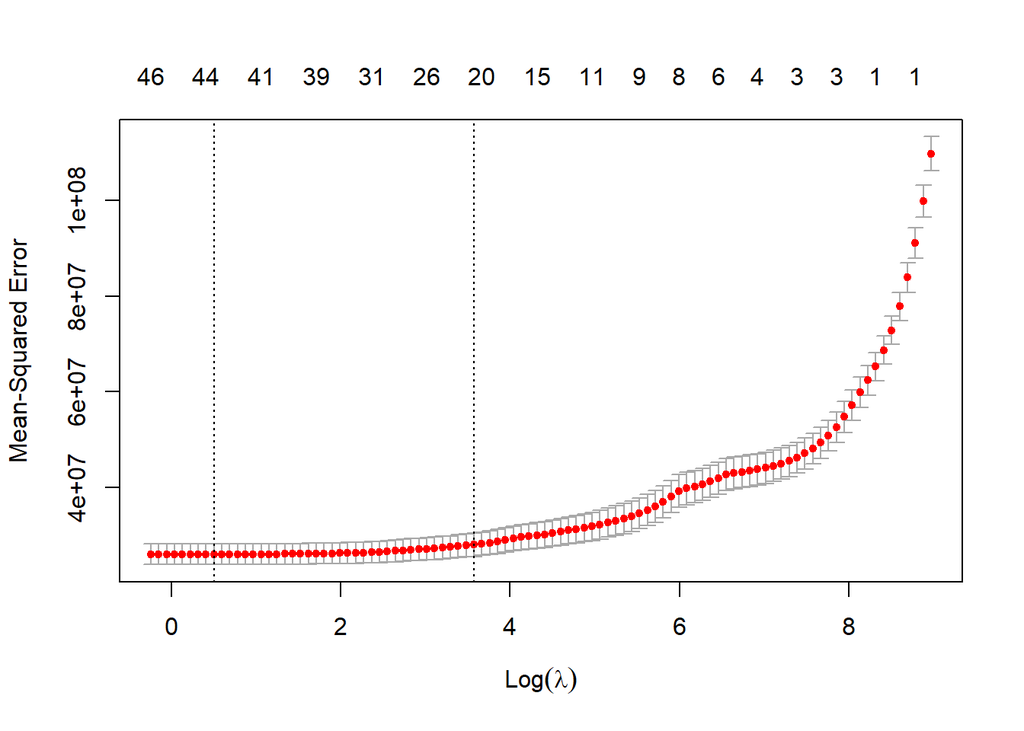

```r
plot(cvfit_17)
```

```r
coef(cvfit_17,s="lambda.1se")
```

```
## 49 x 1 sparse Matrix of class "dgCMatrix"
##                         1
## (Intercept)  1.061644e+04
## day_2_h_0    8.854221e-01
## day_2_h_1    .
## day_2_h_2    .
## day_2_h_3   -5.599336e-01
## day_2_h_4    9.629146e-01
## day_2_h_5    .
## day_2_h_6   -3.356501e-01
## day_2_h_7    .
## day_2_h_8   -5.770352e-01
## day_2_h_9    .
## day_2_h_10   8.053145e-02
## day_2_h_11   .
## day_2_h_12   9.598951e-02
## day_2_h_13   1.741687e-01
## day_2_h_14   .
## day_2_h_15   .
## day_2_h_16   .
## day_2_h_17   .
## day_2_h_18   .
## day_2_h_19   .
## day_2_h_20   8.352260e-02
## day_2_h_21   8.508046e-04
## day_2_h_22  -9.049491e-02
## day_2_h_23  -4.604893e-02
## day_7_h_0    3.292977e-01
## day_7_h_1    1.159218e-03
## day_7_h_2    .
## day_7_h_3    .
## day_7_h_4    .
## day_7_h_5   -1.733295e-01
## day_7_h_6    .
## day_7_h_7    .
## day_7_h_8    7.291539e-02
## day_7_h_9    3.681711e-01
## day_7_h_10   2.696135e-01
## day_7_h_11   .
## day_7_h_12   .
## day_7_h_13  -2.723447e-01
## day_7_h_14   .
## day_7_h_15  -6.042074e-02
## day_7_h_16   .
## day_7_h_17  -7.789932e-02
## day_7_h_18   .
## day_7_h_19   .
## day_7_h_20   .
## day_7_h_21   .
## day_7_h_22  -2.483251e-01
## day_7_h_23   .
```

```r
prediction_df4_17<-predict(cvfit_17,newx = as.matrix(test_df4_17[,-c(1:4)],s=cvfit_17$lambda.1s))
ae_t4_17<-abs(prediction_df4_17/test_df4_17$consumption)
```

### Model for 18:00

```r
train_df4_18<-filter(train_df_4, Saat=="18:00")
test_df4_18<-filter(test_df_4, Saat=="18:00")
cvfit_18=cv.glmnet(as.matrix(train_df4_18[,-c(1:4)]),train_df4_18$consumption,family='gaussian',nfolds=10,set.seed(1))
cvfit_18
```

```
##
## Call:  cv.glmnet(x = as.matrix(train_df4_18[, -c(1:4)]), y = train_df4_18$consumption,      weights = set.seed(1), nfolds = 10, family = "gaussian")
##
## Measure: Mean-Squared Error
##
##     Lambda  Measure      SE Nonzero
## min   0.73 18759037 1657435      47
## 1se  36.26 20381113 1893778      19
```

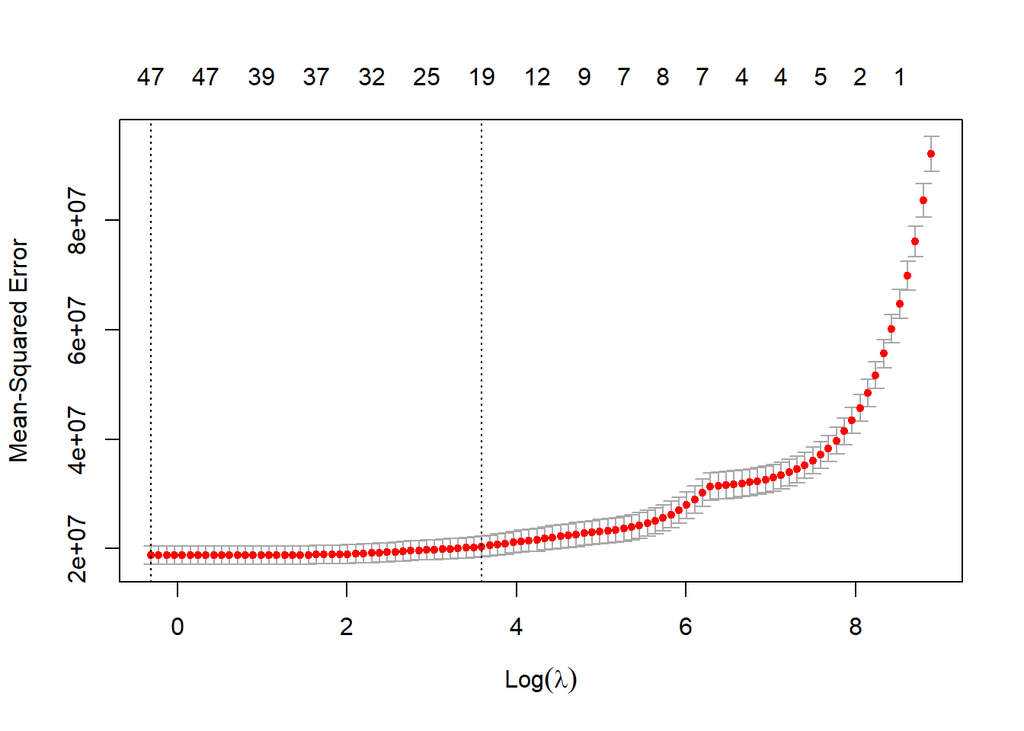

```r
plot(cvfit_18)
```

```r
coef(cvfit_18,s="lambda.1se")
```

```
## 49 x 1 sparse Matrix of class "dgCMatrix"
##                         1
## (Intercept) 9029.95478051
## day_2_h_0      0.98185311
## day_2_h_1      .
## day_2_h_2     -0.02444965
## day_2_h_3      .
## day_2_h_4     -0.25565593
## day_2_h_5      0.62698112
## day_2_h_6      .
## day_2_h_7     -0.32219408
## day_2_h_8      .
## day_2_h_9     -0.49076827
## day_2_h_10     .
## day_2_h_11     0.11013182
## day_2_h_12     0.09821828
## day_2_h_13     0.07902385
## day_2_h_14     .
## day_2_h_15     .
## day_2_h_16     .
## day_2_h_17     .
## day_2_h_18     .
## day_2_h_19     .
## day_2_h_20     .
## day_2_h_21     0.03772014
## day_2_h_22     .
## day_2_h_23    -0.11623485
## day_7_h_0      .
## day_7_h_1      0.19170970
## day_7_h_2      .
## day_7_h_3      .
## day_7_h_4      .
## day_7_h_5      .
## day_7_h_6     -0.07720218
## day_7_h_7      .
## day_7_h_8      .
## day_7_h_9      0.07812950
## day_7_h_10     0.26351620
## day_7_h_11     0.15594471
## day_7_h_12     .
## day_7_h_13     .
## day_7_h_14    -0.08132777
## day_7_h_15     .
## day_7_h_16    -0.12925375
## day_7_h_17     .
## day_7_h_18     .
## day_7_h_19     .
## day_7_h_20     .
## day_7_h_21     .
## day_7_h_22     .
## day_7_h_23    -0.21280158
```

```r
prediction_df4_18<-predict(cvfit_18,newx = as.matrix(test_df4_18[,-c(1:4)],s=cvfit_18$lambda.1s))
ae_t4_18<-abs(prediction_df4_18/test_df4_18$consumption)
```

### Model for 19:00

```r
train_df4_19<-filter(train_df_4, Saat=="19:00")
test_df4_19<-filter(test_df_4, Saat=="19:00")
cvfit_19=cv.glmnet(as.matrix(train_df4_19[,-c(1:4)]),train_df4_19$consumption,family='gaussian',nfolds=10,set.seed(1))
cvfit_19
```

```
##
## Call:  cv.glmnet(x = as.matrix(train_df4_19[, -c(1:4)]), y = train_df4_19$consumption,      weights = set.seed(1), nfolds = 10, family = "gaussian")
##
## Measure: Mean-Squared Error
##
##     Lambda  Measure      SE Nonzero
## min   0.64 15718308 1362995      46
## 1se  26.45 17015338 1623038      21
```

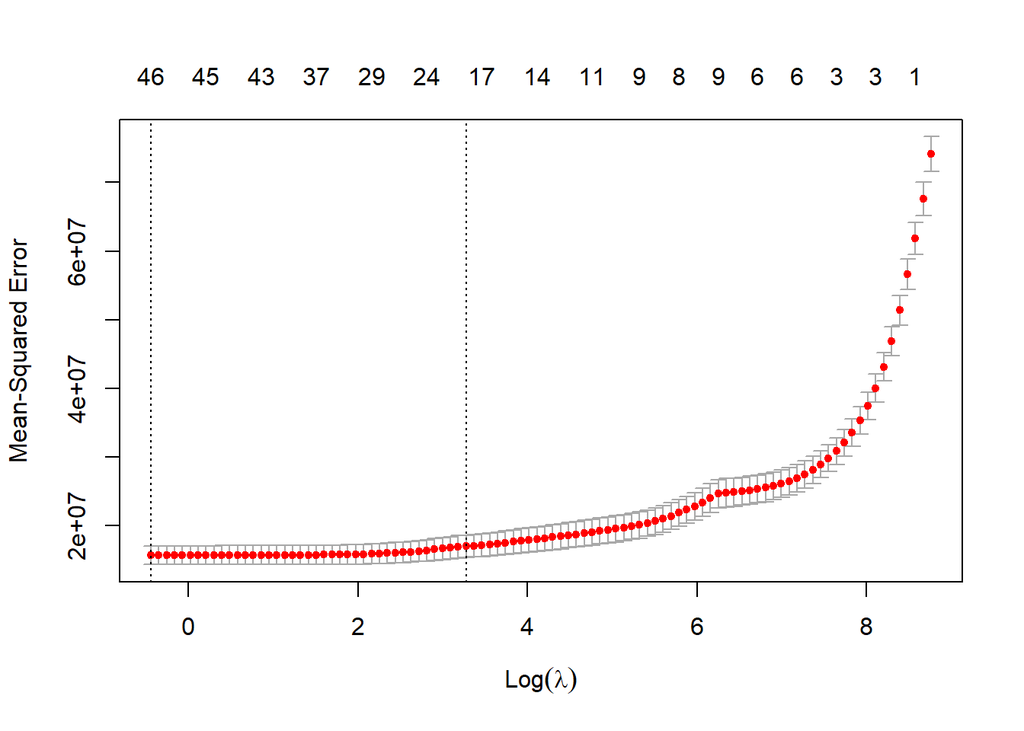

```r
plot(cvfit_19)
```

```r
coef(cvfit_19,s="lambda.1se")
```

```
## 49 x 1 sparse Matrix of class "dgCMatrix"
##                         1
## (Intercept)  8.408594e+03
## day_2_h_0    9.010532e-01
## day_2_h_1    .
## day_2_h_2    .
## day_2_h_3    .
## day_2_h_4    .
## day_2_h_5   -3.494368e-01
## day_2_h_6    6.885018e-01
## day_2_h_7    2.847922e-02
## day_2_h_8   -3.358497e-01
## day_2_h_9    .
## day_2_h_10  -3.277558e-01
## day_2_h_11   .
## day_2_h_12   .
## day_2_h_13   5.773817e-03
## day_2_h_14   2.121490e-02
## day_2_h_15   2.338321e-01
## day_2_h_16   .
## day_2_h_17  -4.751139e-03
## day_2_h_18   .
## day_2_h_19   .
## day_2_h_20   .
## day_2_h_21  -1.054377e-01
## day_2_h_22   .
## day_2_h_23   .
## day_7_h_0   -2.501837e-02
## day_7_h_1    .
## day_7_h_2    1.358878e-01
## day_7_h_3    1.828563e-02
## day_7_h_4    .
## day_7_h_5    .
## day_7_h_6    .
## day_7_h_7   -6.160637e-02
## day_7_h_8    .
## day_7_h_9    .
## day_7_h_10   1.960828e-03
## day_7_h_11   2.533644e-01
## day_7_h_12   1.741037e-01
## day_7_h_13   .
## day_7_h_14  -2.421670e-02
## day_7_h_15   .
## day_7_h_16   .
## day_7_h_17  -2.060080e-01
## day_7_h_18   .
## day_7_h_19   .
## day_7_h_20   .
## day_7_h_21   .
## day_7_h_22   .
## day_7_h_23  -9.745334e-02
```

```r
prediction_df4_19<-predict(cvfit_19,newx = as.matrix(test_df4_19[,-c(1:4)],s=cvfit_19$lambda.1s))
ae_t4_19<-abs(prediction_df4_19/test_df4_19$consumption)
```

### Model for 20:00

```r
train_df4_20<-filter(train_df_4, Saat=="20:00")
test_df4_20<-filter(test_df_4, Saat=="20:00")
cvfit_20=cv.glmnet(as.matrix(train_df4_20[,-c(1:4)]),train_df4_20$consumption,family='gaussian',nfolds=10,set.seed(1))
cvfit_20
```

```
##
## Call:  cv.glmnet(x = as.matrix(train_df4_20[, -c(1:4)]), y = train_df4_20$consumption,      weights = set.seed(1), nfolds = 10, family = "gaussian")
##
## Measure: Mean-Squared Error
##
##     Lambda  Measure      SE Nonzero
## min   1.08 13791275 1250696      41
## 1se  37.14 14930169 1402224      20
```

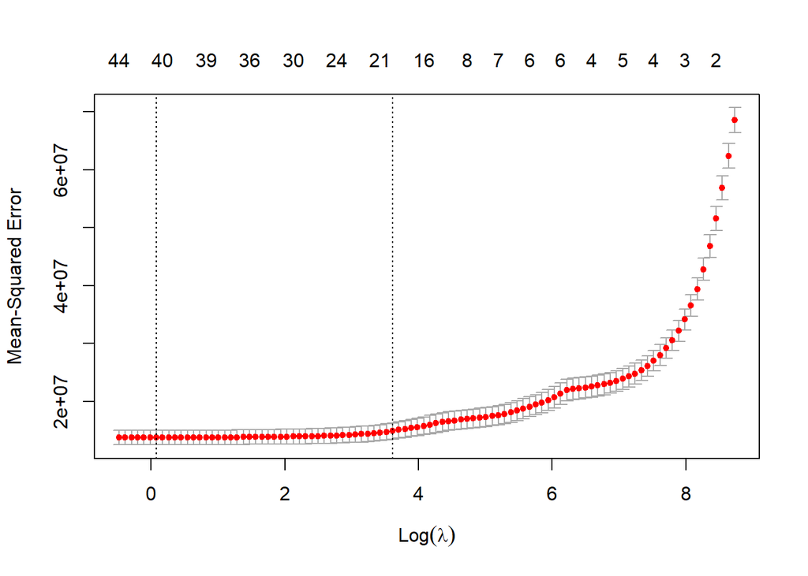

```r
plot(cvfit_20)
```

```r
coef(cvfit_20,s="lambda.1se")
```

```
## 49 x 1 sparse Matrix of class "dgCMatrix"
##                         1
## (Intercept) 6534.60360630
## day_2_h_0      1.05637269
## day_2_h_1     -0.01033926
## day_2_h_2      .
## day_2_h_3      .
## day_2_h_4     -0.12722850
## day_2_h_5      .
## day_2_h_6     -0.22692104
## day_2_h_7      0.43218286
## day_2_h_8      0.05508404
## day_2_h_9     -0.12297847
## day_2_h_10     .
## day_2_h_11    -0.36933965
## day_2_h_12     .
## day_2_h_13     .
## day_2_h_14     .
## day_2_h_15     .
## day_2_h_16     0.30041268
## day_2_h_17     .
## day_2_h_18     .
## day_2_h_19     .
## day_2_h_20     .
## day_2_h_21     .
## day_2_h_22    -0.16491531
## day_2_h_23     .
## day_7_h_0      .
## day_7_h_1     -0.02506314
## day_7_h_2      .
## day_7_h_3      .
## day_7_h_4      0.16487942
## day_7_h_5      .
## day_7_h_6      .
## day_7_h_7      .
## day_7_h_8     -0.03457705
## day_7_h_9      .
## day_7_h_10     .
## day_7_h_11     .
## day_7_h_12     0.13599786
## day_7_h_13     0.30641722
## day_7_h_14     .
## day_7_h_15    -0.24172557
## day_7_h_16     .
## day_7_h_17     .
## day_7_h_18    -0.01881742
## day_7_h_19     .
## day_7_h_20    -0.05683330
## day_7_h_21    -0.05513199
## day_7_h_22     .
## day_7_h_23    -0.03050000
```

```r
prediction_df4_20<-predict(cvfit_20,newx = as.matrix(test_df4_20[,-c(1:4)],s=cvfit_20$lambda.1s))
ae_t4_20<-abs(prediction_df4_20/test_df4_20$consumption)
```

### Model for 21:00

```r
train_df4_21<-filter(train_df_4, Saat=="21:00")
test_df4_21<-filter(test_df_4, Saat=="21:00")
cvfit_21=cv.glmnet(as.matrix(train_df4_21[,-c(1:4)]),train_df4_21$consumption,family='gaussian',nfolds=10,set.seed(1))
cvfit_21
```

```
##
## Call:  cv.glmnet(x = as.matrix(train_df4_21[, -c(1:4)]), y = train_df4_21$consumption,      weights = set.seed(1), nfolds = 10, family = "gaussian")
##
## Measure: Mean-Squared Error
##
##     Lambda  Measure      SE Nonzero
## min   1.01 13151134 1208311      41
## 1se  37.85 14283346 1313757      20
```

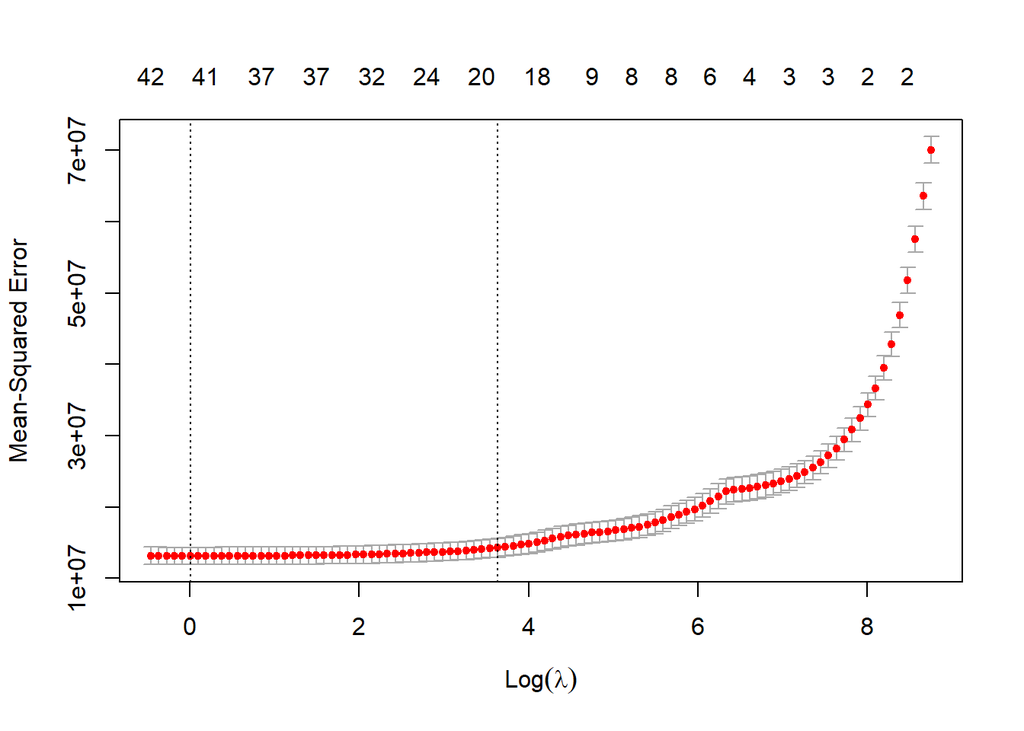

```r
plot(cvfit_21)
```

```r
coef(cvfit_21,s="lambda.1se")
```

```
## 49 x 1 sparse Matrix of class "dgCMatrix"
##                         1
## (Intercept)  6.322586e+03
## day_2_h_0    1.104970e+00
## day_2_h_1    .
## day_2_h_2    .
## day_2_h_3    .
## day_2_h_4    .
## day_2_h_5   -2.286840e-01
## day_2_h_6    .
## day_2_h_7   -1.689355e-02
## day_2_h_8    2.959472e-01
## day_2_h_9    .
## day_2_h_10  -3.513586e-02
## day_2_h_11   .
## day_2_h_12  -4.017784e-01
## day_2_h_13   .
## day_2_h_14   .
## day_2_h_15   .
## day_2_h_16   2.044233e-01
## day_2_h_17   8.549106e-02
## day_2_h_18   .
## day_2_h_19   .
## day_2_h_20   .
## day_2_h_21   .
## day_2_h_22   .
## day_2_h_23  -1.881959e-01
## day_7_h_0    1.476897e-01
## day_7_h_1    .
## day_7_h_2   -2.051078e-01
## day_7_h_3   -9.980579e-15
## day_7_h_4    2.041588e-01
## day_7_h_5    .
## day_7_h_6    .
## day_7_h_7    .
## day_7_h_8    .
## day_7_h_9    .
## day_7_h_10   .
## day_7_h_11   .
## day_7_h_12   .
## day_7_h_13   1.137509e-01
## day_7_h_14   3.175457e-01
## day_7_h_15   .
## day_7_h_16  -2.572342e-01
## day_7_h_17   .
## day_7_h_18   .
## day_7_h_19  -1.172448e-02
## day_7_h_20   .
## day_7_h_21  -5.263938e-02
## day_7_h_22  -3.090239e-02
## day_7_h_23  -8.468415e-02
```

```r
prediction_df4_21<-predict(cvfit_21,newx = as.matrix(test_df4_21[,-c(1:4)],s=cvfit_21$lambda.1s))
ae_t4_21<-abs(prediction_df4_21/test_df4_21$consumption)
```

### Model for 22:00

```r
train_df4_22<-filter(train_df_4, Saat=="22:00")
test_df4_22<-filter(test_df_4, Saat=="22:00")
cvfit_22=cv.glmnet(as.matrix(train_df4_22[,-c(1:4)]),train_df4_22$consumption,family='gaussian',nfolds=10,set.seed(1))
cvfit_22
```

```
##
## Call:  cv.glmnet(x = as.matrix(train_df4_22[, -c(1:4)]), y = train_df4_22$consumption,      weights = set.seed(1), nfolds = 10, family = "gaussian")
##
## Measure: Mean-Squared Error
##
##     Lambda  Measure      SE Nonzero
## min  0.616 13277750 1340532      43
## 1se 30.667 14546444 1480223      22
```

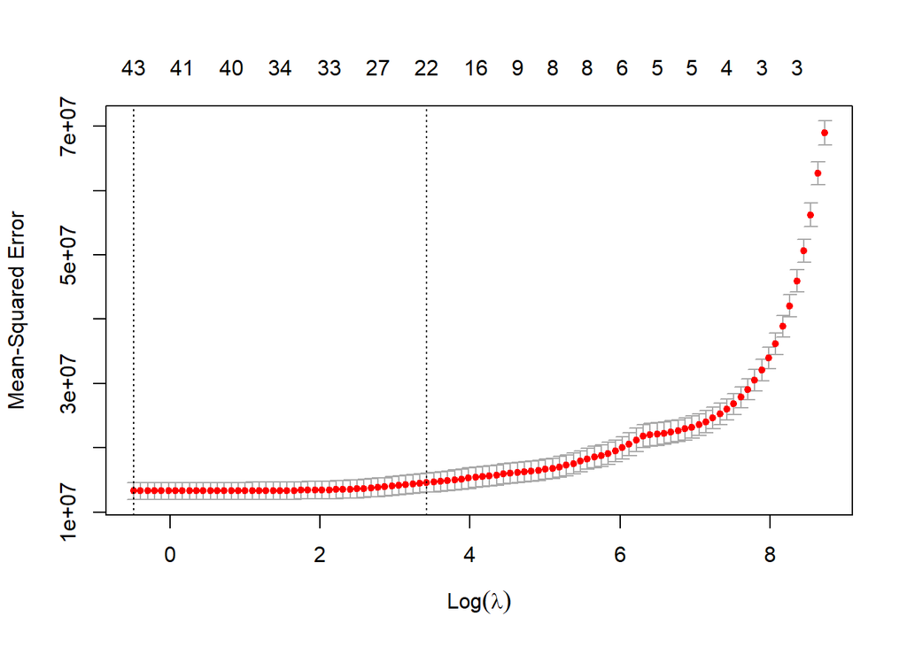

```r
plot(cvfit_22)
```

```r
coef(cvfit_22,s="lambda.1se")
```

```
## 49 x 1 sparse Matrix of class "dgCMatrix"
##                         1
## (Intercept)  4.714323e+03
## day_2_h_0    1.024360e+00
## day_2_h_1    2.003809e-01
## day_2_h_2    .
## day_2_h_3   -1.298682e-01
## day_2_h_4    .
## day_2_h_5    .
## day_2_h_6   -1.261211e-01
## day_2_h_7    .
## day_2_h_8   -1.454542e-01
## day_2_h_9    3.843069e-01
## day_2_h_10   4.110980e-03
## day_2_h_11  -5.622463e-02
## day_2_h_12   .
## day_2_h_13  -4.054100e-01
## day_2_h_14   .
## day_2_h_15   .
## day_2_h_16   .
## day_2_h_17   1.222573e-01
## day_2_h_18   1.158675e-01
## day_2_h_19   .
## day_2_h_20   .
## day_2_h_21   .
## day_2_h_22   .
## day_2_h_23  -1.639881e-01
## day_7_h_0    5.300962e-02
## day_7_h_1    .
## day_7_h_2    .
## day_7_h_3    .
## day_7_h_4    .
## day_7_h_5    8.179574e-02
## day_7_h_6    4.429384e-02
## day_7_h_7    .
## day_7_h_8    .
## day_7_h_9    .
## day_7_h_10  -1.656902e-02
## day_7_h_11   .
## day_7_h_12   .
## day_7_h_13   .
## day_7_h_14   1.165220e-01
## day_7_h_15   3.379520e-01
## day_7_h_16   .
## day_7_h_17  -2.920097e-01
## day_7_h_18   .
## day_7_h_19   .
## day_7_h_20  -3.771208e-03
## day_7_h_21   .
## day_7_h_22  -4.020677e-03
## day_7_h_23  -1.911180e-01
```

```r
prediction_df4_22<-predict(cvfit_22,newx = as.matrix(test_df4_22[,-c(1:4)],s=cvfit_22$lambda.1s))
ae_t4_22<-abs(prediction_df4_22/test_df4_22$consumption)
```

### Model for 23:00

```r
train_df4_23<-filter(train_df_4, Saat=="23:00")
test_df4_23<-filter(test_df_4, Saat=="23:00")
cvfit_23=cv.glmnet(as.matrix(train_df4_23[,-c(1:4)]),train_df4_23$consumption,family='gaussian',nfolds=10,set.seed(1))
cvfit_23
```

```
##
## Call:  cv.glmnet(x = as.matrix(train_df4_23[, -c(1:4)]), y = train_df4_23$consumption,      weights = set.seed(1), nfolds = 10, family = "gaussian")
##
## Measure: Mean-Squared Error
##
##     Lambda  Measure      SE Nonzero
## min   0.64 11744294 1112566      45
## 1se  38.48 12850061 1293569      15
```

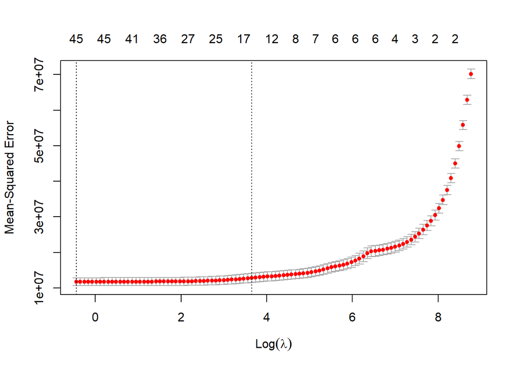

```r
plot(cvfit_23)
```

```r
coef(cvfit_23,s="lambda.1se")
```

```
## 49 x 1 sparse Matrix of class "dgCMatrix"
##                         1
## (Intercept) 3111.59557176
## day_2_h_0      1.09468393
## day_2_h_1      .
## day_2_h_2      0.05703696
## day_2_h_3      .
## day_2_h_4     -0.02492724
## day_2_h_5      .
## day_2_h_6      .
## day_2_h_7     -0.06164914
## day_2_h_8      .
## day_2_h_9      .
## day_2_h_10     0.14240927
## day_2_h_11     .
## day_2_h_12    -0.09820305
## day_2_h_13     .
## day_2_h_14    -0.32504521
## day_2_h_15     .
## day_2_h_16     .
## day_2_h_17     .
## day_2_h_18     .
## day_2_h_19     .
## day_2_h_20     .
## day_2_h_21     .
## day_2_h_22     .
## day_2_h_23    -0.02394715
## day_7_h_0      0.15141651
## day_7_h_1      .
## day_7_h_2      .
## day_7_h_3      .
## day_7_h_4     -0.15291960
## day_7_h_5      .
## day_7_h_6      0.13573687
## day_7_h_7      .
## day_7_h_8      .
## day_7_h_9      .
## day_7_h_10     .
## day_7_h_11     .
## day_7_h_12     .
## day_7_h_13     .
## day_7_h_14     .
## day_7_h_15     0.23937860
## day_7_h_16     0.10979498
## day_7_h_17     .
## day_7_h_18    -0.13418346
## day_7_h_19     .
## day_7_h_20     .
## day_7_h_21     .
## day_7_h_22     .
## day_7_h_23    -0.25446430
```

```r
prediction_df4_23<-predict(cvfit_23,newx = as.matrix(test_df4_23[,-c(1:4)],s=cvfit_23$lambda.1s))
ae_t4_23<-abs(prediction_df4_23/test_df4_23$consumption)
```

Looking at the mape scores, lasso model perform worse than hourly linear regression model. Comparison of the five models in terms of test performance can be found below.

```r
ape_t4<-rbind(ae_t4_0,ae_t4_1,ae_t4_2,ae_t4_3,ae_t4_4,ae_t4_5,ae_t4_6,ae_t4_7,ae_t4_8,ae_t4_9,ae_t4_10,ae_t4_11,ae_t4_12,ae_t4_13,ae_t4_14,ae_t4_15,ae_t4_16,ae_t4_17,ae_t4_18,ae_t4_19,ae_t4_20,ae_t4_21,ae_t4_22,ae_t4_23)

mape_t4<-mean(ape_t4)
mape_scores_4<-cbind(mape_scores_3,mape_hourly_lasso=mape_t4)
mape_scores_4
```

```
##      naive_lag_168 naive_lag_48  mape_reg mape_hourly mape_hourly_lasso
## [1,]     0.8926363     1.185193 0.9923565   0.9841826         0.9887389
```

## TASK 5

Boxplots below show the absolute percentage errors for different modeling approaches. Mean of the absolute percentage errors are very close to each other. However, variance differs between those approaches. In naive 2 days ago prediction model, the APE value have a large variance, which decreases the reliability of the model. Between the models 1 week lagged naive approach has the minimum variance in terms of ape scores.

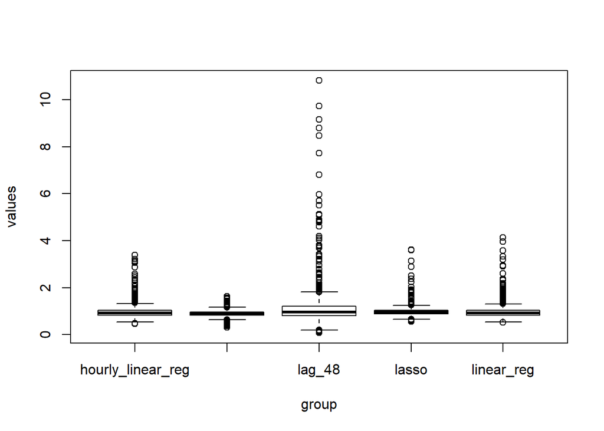

```r
ape_t1_48<-as.vector(ape_t1_48)
ape_t1_168<-as.vector(ape_t1_168)
ape_t2<-as.vector(ape_t2)
ape_t3<-as.vector(ape_t3)
ape_t4<-as.vector(ape_t4)

ape_scores<- data.frame(values = c(ape_t1_48, ape_t1_168,ape_t2,ape_t3,ape_t4),group =c(rep("lag_48",length(ape_t1_48)),rep("lag_168",length(ape_t1_168)),rep("linear_reg",length(ape_t2)),rep("hourly_linear_reg",length(ape_t3)),rep("lasso",length(ape_t4))))

boxplot(values ~ group, ape_scores)
```